# glinski_metabolites

# dia

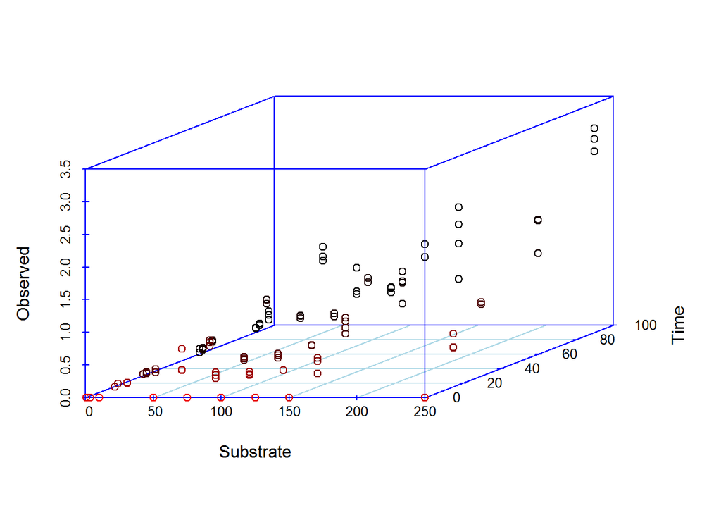

The above figure shows a three-dimensional plot of pesticide substrate concentration, observed concentration and experiment time. We need to condition the pesticide data on the substrate concentrations used in the experiment and regress the observed concentrations over the 90 min period in order to estimate the linear slopes for the Michaelis-Menten kinetic rate constants.

```
## [1] "Substrates:"
```

```
## [1] "##################################################"
## [1] "Substrate =  50"
##  [1] "Indices =  1"  "Indices =  2"  "Indices =  3"  "Indices =  4"
##  [5] "Indices =  5"  "Indices =  6"  "Indices =  7"  "Indices =  8"
##  [9] "Indices =  9"  "Indices =  10" "Indices =  11" "Indices =  12"
## [13] "Indices =  13" "Indices =  14" "Indices =  15"
##  [1] "Times = 0"  "Times = 0"  "Times = 0"  "Times = 15" "Times = 15"
##  [6] "Times = 15" "Times = 30" "Times = 30" "Times = 30" "Times = 60"
## [11] "Times = 60" "Times = 60" "Times = 90" "Times = 90" "Times = 90"
##  [1] "Concs = 0"           "Concs = 0"           "Concs = 0"
##  [4] "Concs = 0.585463603" "Concs = 0.261545192" "Concs = 0.250839807"
##  [7] "Concs = 0.51028234"  "Concs = 0.542636363" "Concs = 0.456010453"
## [10] "Concs = 0.771175727" "Concs = 0.831308115" "Concs = 0.840152987"
## [13] "Concs = 1.307705125" "Concs = 1.163648794" "Concs = 1.092201395"
## Call:
## rlm(formula = Observed[ind] ~ Time[ind])
## Converged in 4 iterations
##
## Coefficients:
## (Intercept)   Time[ind]
##  0.06775371  0.01264067
##
## Degrees of freedom: 15 total; 13 residual
## Scale estimate: 0.0938
##
## Call: rlm(formula = Observed[ind] ~ Time[ind])
## Residuals:
##       Min        1Q    Median        3Q       Max
## -0.113213 -0.061386  0.004181  0.038634  0.328100
##
## Coefficients:
##             Value   Std. Error t value
## (Intercept)  0.0678  0.0324     2.0888
## Time[ind]    0.0126  0.0006    19.7373
##
## Residual standard error: 0.09385 on 13 degrees of freedom
```

```
## (Intercept)   Time[ind]
##  0.06775371  0.01264067
##             2.5 % 97.5 %
## (Intercept)    NA     NA
## Time[ind]      NA     NA
## [1] "##################################################"
## [1] "##################################################"
## [1] "Substrate =  10"
##  [1] "Indices =  16" "Indices =  17" "Indices =  18" "Indices =  19"
##  [5] "Indices =  20" "Indices =  21" "Indices =  22" "Indices =  23"
##  [9] "Indices =  24" "Indices =  25" "Indices =  26" "Indices =  27"
## [13] "Indices =  28" "Indices =  29" "Indices =  30" "Indices =  31"
##  [1] "Times = 0"  "Times = 0"  "Times = 0"  "Times = 15" "Times = 15"
##  [6] "Times = 15" "Times = 30" "Times = 30" "Times = 30" "Times = 60"
## [11] "Times = 60" "Times = 60" "Times = 60" "Times = 90" "Times = 90"
## [16] "Times = 90"
##  [1] "Concs = 0"           "Concs = 0"           "Concs = 0"
##  [4] "Concs = 0.063028732" "Concs = 0.056638774" "Concs = NA"
##  [7] "Concs = 0.102314087" "Concs = 0.102958703" "Concs = 0.055763938"
## [10] "Concs = NA"          "Concs = 0.214565616" "Concs = 0.202136134"
## [13] "Concs = 0.190219138" "Concs = 0.190000776" "Concs = 0.325779675"
## [16] "Concs = 0.26769978"
```

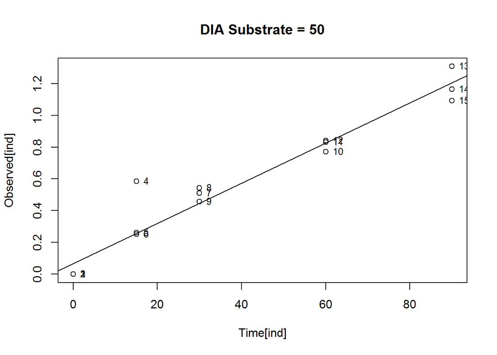

```
## Call:
## rlm(formula = Observed[ind] ~ Time[ind])
## Ran 20 iterations without convergence
##
## Coefficients:
## (Intercept)   Time[ind]
## 0.005144853 0.003125718
##
## Degrees of freedom: 14 total; 12 residual
##   (2 observations deleted due to missingness)
## Scale estimate: 0.0108
##
## Call: rlm(formula = Observed[ind] ~ Time[ind])
## Residuals:
##        Min         1Q     Median         3Q        Max
## -0.0964587 -0.0051449  0.0004644  0.0082382  0.0393202
##
## Coefficients:
##             Value   Std. Error t value
## (Intercept)  0.0051  0.0078     0.6607
## Time[ind]    0.0031  0.0001    20.9819
##
## Residual standard error: 0.01083 on 12 degrees of freedom
##   (2 observations deleted due to missingness)
```

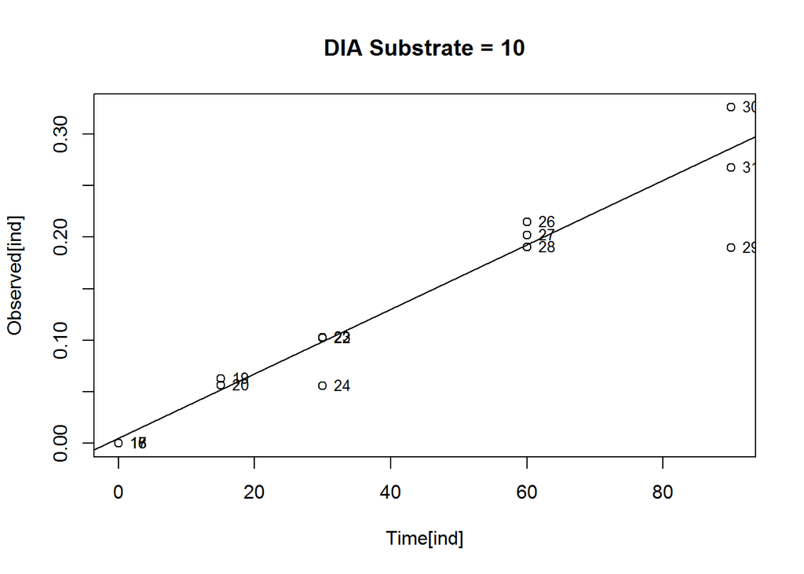

```
## (Intercept)   Time[ind]
## 0.005144853 0.003125718
##             2.5 % 97.5 %
## (Intercept)    NA     NA
## Time[ind]      NA     NA
## [1] "##################################################"
## [1] "##################################################"
## [1] "Substrate =  100"
##  [1] "Indices =  32" "Indices =  33" "Indices =  34" "Indices =  35"
##  [5] "Indices =  36" "Indices =  37" "Indices =  38" "Indices =  39"
##  [9] "Indices =  40" "Indices =  41" "Indices =  42" "Indices =  43"
## [13] "Indices =  44" "Indices =  45" "Indices =  46"
##  [1] "Times = 0"  "Times = 0"  "Times = 0"  "Times = 15" "Times = 15"
##  [6] "Times = 15" "Times = 30" "Times = 30" "Times = 30" "Times = 60"
## [11] "Times = 60" "Times = 60" "Times = 90" "Times = 90" "Times = 90"
##  [1] "Concs = 0"           "Concs = 0"           "Concs = 0"
##  [4] "Concs = 0.199686369" "Concs = 0.226193885" "Concs = 0.183498938"
##  [7] "Concs = 0.277277734" "Concs = 0.320753808" "Concs = 0.342265185"
## [10] "Concs = 0.577987791" "Concs = 0.621738846" "Concs = 0.622069014"
## [13] "Concs = 0.690327949" "Concs = 0.607358803" "Concs = 0.673085734"
## Call:
## rlm(formula = Observed[ind] ~ Time[ind])
## Converged in 5 iterations
##
## Coefficients:
## (Intercept)   Time[ind]
## 0.067751080 0.007403565
##
## Degrees of freedom: 15 total; 13 residual
## Scale estimate: 0.0904
##
## Call: rlm(formula = Observed[ind] ~ Time[ind])
## Residuals:
##       Min        1Q    Median        3Q       Max
## -0.126713 -0.064369  0.004694  0.049898  0.110104
##
## Coefficients:
##             Value   Std. Error t value
## (Intercept)  0.0678  0.0320     2.1186
## Time[ind]    0.0074  0.0006    11.7251
##
## Residual standard error: 0.09041 on 13 degrees of freedom
```

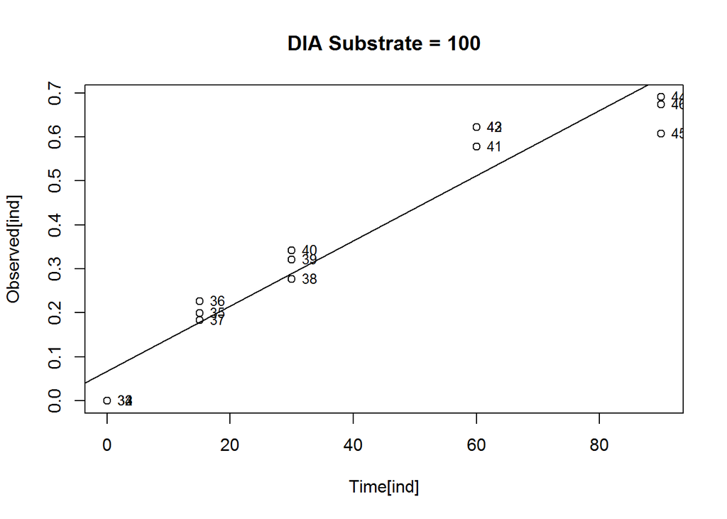

```
## (Intercept)   Time[ind]
## 0.067751080 0.007403565
##             2.5 % 97.5 %
## (Intercept)    NA     NA
## Time[ind]      NA     NA
## [1] "##################################################"
## [1] "##################################################"
## [1] "Substrate =  75"
##  [1] "Indices =  47" "Indices =  48" "Indices =  49" "Indices =  50"
##  [5] "Indices =  51" "Indices =  52" "Indices =  53" "Indices =  54"
##  [9] "Indices =  55" "Indices =  56" "Indices =  57" "Indices =  58"
## [13] "Indices =  59" "Indices =  60" "Indices =  61"
##  [1] "Times = 0"  "Times = 0"  "Times = 0"  "Times = 15" "Times = 15"
##  [6] "Times = 15" "Times = 30" "Times = 30" "Times = 30" "Times = 60"
## [11] "Times = 60" "Times = 60" "Times = 90" "Times = 90" "Times = 90"
##  [1] "Concs = 0"           "Concs = 0"           "Concs = 0"
##  [4] "Concs = 0.181875613" "Concs = 0.220572965" "Concs = 0.134445009"
##  [7] "Concs = 0.271493213" "Concs = 0.240135574" "Concs = 0.294733329"
## [10] "Concs = 0.549334509" "Concs = 0.593493808" "Concs = 0.579429136"
## [13] "Concs = 0.626545938" "Concs = 0.989677724" "Concs = 0.589031821"
## Call:
## rlm(formula = Observed[ind] ~ Time[ind])
## Converged in 9 iterations
##
## Coefficients:
## (Intercept)   Time[ind]
## 0.021326852 0.008701103
##
## Degrees of freedom: 15 total; 13 residual
## Scale estimate: 0.0445
##
## Call: rlm(formula = Observed[ind] ~ Time[ind])
## Residuals:
##      Min       1Q   Median       3Q      Max
## -0.21539 -0.02133 -0.01087  0.03303  0.18525
##
## Coefficients:
##             Value   Std. Error t value
## (Intercept)  0.0213  0.0243     0.8769
## Time[ind]    0.0087  0.0005    18.1203
##
## Residual standard error: 0.04452 on 13 degrees of freedom
```

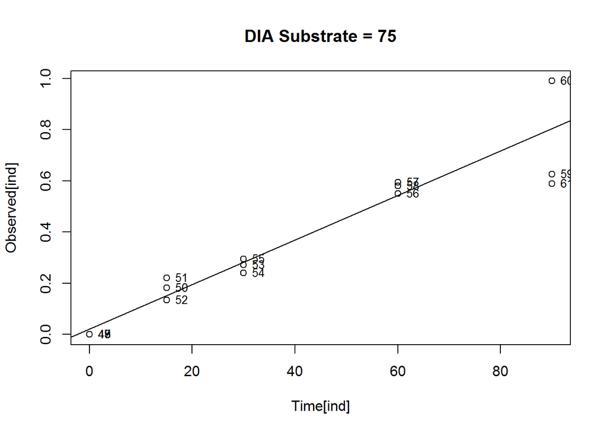

```
## (Intercept)   Time[ind]
## 0.021326852 0.008701103
##             2.5 % 97.5 %
## (Intercept)    NA     NA
## Time[ind]      NA     NA
## [1] "##################################################"
## [1] "##################################################"
## [1] "Substrate =  125"
##  [1] "Indices =  62" "Indices =  63" "Indices =  64" "Indices =  65"
##  [5] "Indices =  66" "Indices =  67" "Indices =  68" "Indices =  69"
##  [9] "Indices =  70" "Indices =  71"
##  [1] "Times = 0"  "Times = 0"  "Times = 15" "Times = 15" "Times = 30"
##  [6] "Times = 30" "Times = 60" "Times = 60" "Times = 90" "Times = 90"
##  [1] "Concs = 0"           "Concs = 0"           "Concs = 0.25671841"
##  [4] "Concs = 0.250484194" "Concs = 0.468843857" "Concs = 0.464918482"
##  [7] "Concs = 1.103609505" "Concs = 1.162619293" "Concs = 1.351454855"
## [10] "Concs = 1.149727466"
## Call:
## rlm(formula = Observed[ind] ~ Time[ind])
## Converged in 9 iterations
##
## Coefficients:
## (Intercept)   Time[ind]
##  0.01891677  0.01495899
##
## Degrees of freedom: 10 total; 8 residual
## Scale estimate: 0.0242
##
## Call: rlm(formula = Observed[ind] ~ Time[ind])
## Residuals:
##        Min         1Q     Median         3Q        Max
## -0.2154981 -0.0176303 -0.0008052  0.0118583  0.2461633
##
## Coefficients:
##             Value   Std. Error t value
## (Intercept)  0.0189  0.0181     1.0477
## Time[ind]    0.0150  0.0004    41.9602
##
## Residual standard error: 0.02425 on 8 degrees of freedom
```

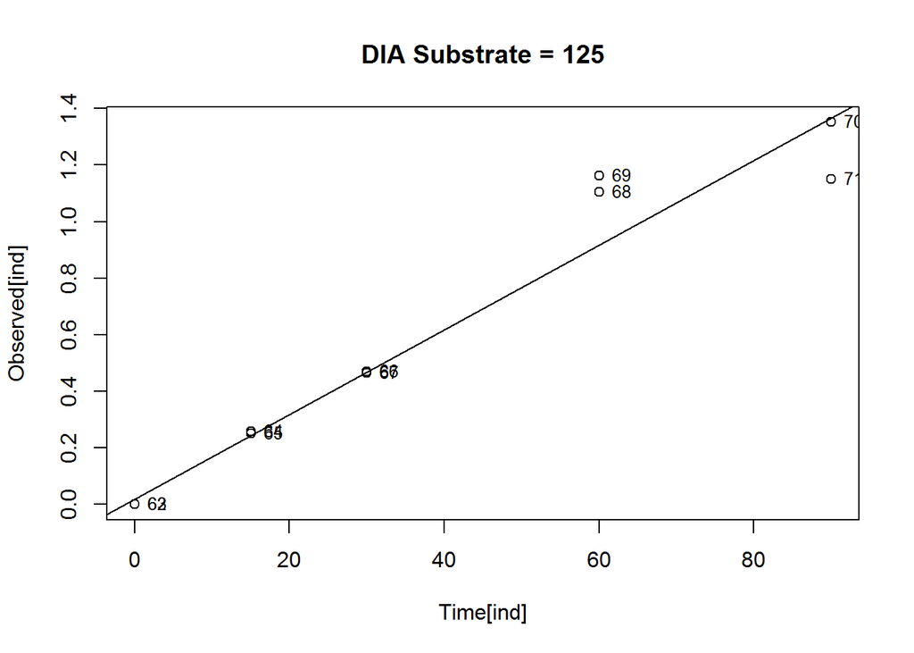

```
## (Intercept)   Time[ind]
##  0.01891677  0.01495899
##             2.5 % 97.5 %
## (Intercept)    NA     NA
## Time[ind]      NA     NA
## [1] "##################################################"
## [1] "##################################################"
## [1] "Substrate =  0.712"
##  [1] "Indices =  72" "Indices =  73" "Indices =  74" "Indices =  75"
##  [5] "Indices =  76" "Indices =  77" "Indices =  78" "Indices =  79"
##  [9] "Indices =  80" "Indices =  81"
##  [1] "Times = 0"  "Times = 0"  "Times = 15" "Times = 15" "Times = 15"
##  [6] "Times = 30" "Times = 60" "Times = 60" "Times = 90" "Times = 90"
##  [1] "Concs = 0"           "Concs = 0"           "Concs = 0"
##  [4] "Concs = 0"           "Concs = 0"           "Concs = 0.026940754"
##  [7] "Concs = 0.080149289" "Concs = 0.027380501" "Concs = 0.061935383"
## [10] "Concs = 0.071298111"
## Call:
## rlm(formula = Observed[ind] ~ Time[ind])
## Converged in 6 iterations
##
## Coefficients:
##   (Intercept)     Time[ind]
## -0.0053994871  0.0007975344
##
## Degrees of freedom: 10 total; 8 residual
## Scale estimate: 0.00973
##
## Call: rlm(formula = Observed[ind] ~ Time[ind])
## Residuals:
##        Min         1Q     Median         3Q        Max
## -0.0150721 -0.0065635  0.0002381  0.0053995  0.0376967
##
## Coefficients:
##             Value   Std. Error t value
## (Intercept) -0.0054  0.0057    -0.9527
## Time[ind]    0.0008  0.0001     7.0325
##
## Residual standard error: 0.009731 on 8 degrees of freedom
```

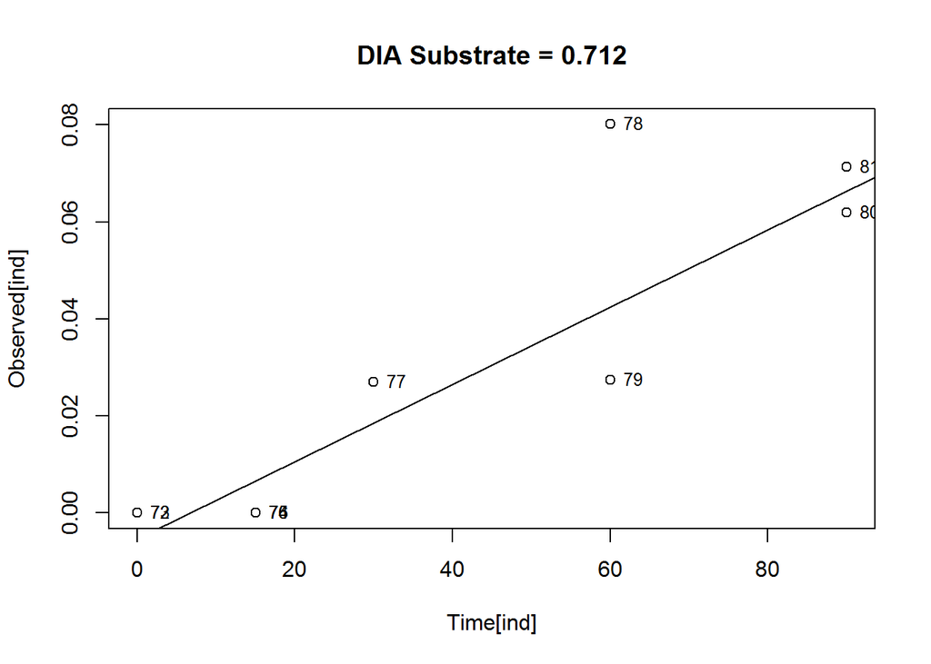

```
##   (Intercept)     Time[ind]
## -0.0053994871  0.0007975344
##             2.5 % 97.5 %
## (Intercept)    NA     NA
## Time[ind]      NA     NA
## [1] "##################################################"
## [1] "##################################################"
## [1] "Substrate =  3.1684"
##  [1] "Indices =  82" "Indices =  83" "Indices =  84" "Indices =  85"
##  [5] "Indices =  86" "Indices =  87" "Indices =  88" "Indices =  89"
##  [9] "Indices =  90" "Indices =  91" "Indices =  92" "Indices =  93"
## [13] "Indices =  94"
##  [1] "Times = 0"  "Times = 0"  "Times = 0"  "Times = 15" "Times = 15"
##  [6] "Times = 30" "Times = 30" "Times = 30" "Times = 60" "Times = 60"
## [11] "Times = 60" "Times = 90" "Times = 90"
##  [1] "Concs = 0"           "Concs = 0"           "Concs = 0"
##  [4] "Concs = 0.049477598" "Concs = 0.049432813" "Concs = 0.050456874"
##  [7] "Concs = 0.063998501" "Concs = 0.037395121" "Concs = 0.068845504"
## [10] "Concs = 0.083597324" "Concs = 0.096720338" "Concs = 0.108999109"
## [13] "Concs = 0.135728061"
## Call:
## rlm(formula = Observed[ind] ~ Time[ind])
## Converged in 1 iterations
##
## Coefficients:
## (Intercept)   Time[ind]
## 0.011168802 0.001248868
##
## Degrees of freedom: 13 total; 11 residual
## Scale estimate: 0.0167
##
## Call: rlm(formula = Observed[ind] ~ Time[ind])
## Residuals:
##       Min        1Q    Median        3Q       Max
## -0.017255 -0.011169 -0.002504  0.012161  0.019576
##
## Coefficients:
##             Value  Std. Error t value
## (Intercept) 0.0112 0.0062     1.7952
## Time[ind]   0.0012 0.0001     9.6669
##
## Residual standard error: 0.01666 on 11 degrees of freedom
```

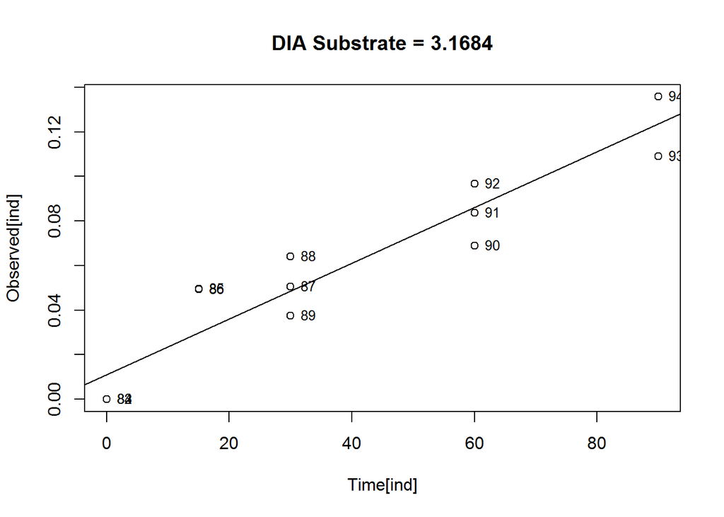

```
## (Intercept)   Time[ind]
## 0.011168802 0.001248868
##             2.5 % 97.5 %
## (Intercept)    NA     NA
## Time[ind]      NA     NA
## [1] "##################################################"
## [1] "##################################################"
## [1] "Substrate =  250"
##  [1] "Indices =  95"  "Indices =  96"  "Indices =  97"  "Indices =  98"
##  [5] "Indices =  99"  "Indices =  100" "Indices =  101" "Indices =  102"
##  [9] "Indices =  103" "Indices =  104" "Indices =  105" "Indices =  106"
## [13] "Indices =  107" "Indices =  108" "Indices =  109"
##  [1] "Times = 0"  "Times = 0"  "Times = 0"  "Times = 15" "Times = 15"
##  [6] "Times = 15" "Times = 30" "Times = 30" "Times = 30" "Times = 60"
## [11] "Times = 60" "Times = 60" "Times = 90" "Times = 90" "Times = 90"
##  [1] "Concs = 0"           "Concs = 0"           "Concs = 0"
##  [4] "Concs = 0.595748019" "Concs = 0.609228827" "Concs = 0.810403963"
##  [7] "Concs = 1.130313908" "Concs = NA"          "Concs = 1.094019425"
## [10] "Concs = 2.040786946" "Concs = 2.060489665" "Concs = 1.546144988"
## [13] "Concs = 3.125991996" "Concs = 2.961111344" "Concs = 2.766158119"
## Call:
## rlm(formula = Observed[ind] ~ Time[ind])
## Converged in 9 iterations
##
## Coefficients:
## (Intercept)   Time[ind]
##  0.08547631  0.03207666
##
## Degrees of freedom: 14 total; 12 residual
##   (1 observation deleted due to missingness)
## Scale estimate: 0.125
##
## Call: rlm(formula = Observed[ind] ~ Time[ind])
## Residuals:
##      Min       1Q   Median       3Q      Max
## -0.46393 -0.08548  0.02992  0.04937  0.24378
##
## Coefficients:
##             Value   Std. Error t value
## (Intercept)  0.0855  0.0605     1.4127
## Time[ind]    0.0321  0.0012    27.4658
##
## Residual standard error: 0.1246 on 12 degrees of freedom
##   (1 observation deleted due to missingness)
```

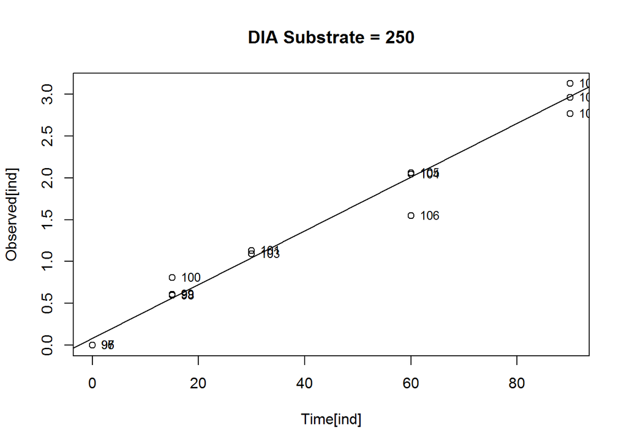

```
## (Intercept)   Time[ind]
##  0.08547631  0.03207666
##             2.5 % 97.5 %
## (Intercept)    NA     NA
## Time[ind]      NA     NA
## [1] "##################################################"
## [1] "##################################################"
## [1] "Substrate =  150"
##  [1] "Indices =  110" "Indices =  111" "Indices =  112" "Indices =  113"
##  [5] "Indices =  114" "Indices =  115" "Indices =  116" "Indices =  117"
##  [9] "Indices =  118" "Indices =  119" "Indices =  120" "Indices =  121"
## [13] "Indices =  122" "Indices =  123" "Indices =  124" "Indices =  125"
## [17] "Indices =  126" "Indices =  127" "Indices =  128" "Indices =  129"
##  [1] "Times = 0"  "Times = 0"  "Times = 0"  "Times = 0"  "Times = 15"
##  [6] "Times = 15" "Times = 15" "Times = 15" "Times = 30" "Times = 30"
## [11] "Times = 30" "Times = 30" "Times = 60" "Times = 60" "Times = 60"
## [16] "Times = 60" "Times = 90" "Times = 90" "Times = 90" "Times = 90"
##  [1] "Concs = 0"           "Concs = 0"           "Concs = 0"
##  [4] "Concs = 0"           "Concs = 0.397134148" "Concs = 0.200692165"
##  [7] "Concs = 0.438951389" "Concs = 0.389074132" "Concs = 0.735668645"
## [10] "Concs = 0.641012348" "Concs = 0.895177769" "Concs = 0.833089226"
## [13] "Concs = 1.091832924" "Concs = 0.77221084"  "Concs = 1.267592057"
## [16] "Concs = 1.113093549" "Concs = 1.656276416" "Concs = 0.817747445"
## [19] "Concs = 1.357629712" "Concs = 1.915166937"
## Call:
## rlm(formula = Observed[ind] ~ Time[ind])
## Converged in 16 iterations
##
## Coefficients:
## (Intercept)   Time[ind]
##  0.09310748  0.01699426
##
## Degrees of freedom: 20 total; 18 residual
## Scale estimate: 0.138
##
## Call: rlm(formula = Observed[ind] ~ Time[ind])
## Residuals:
##      Min       1Q   Median       3Q      Max
## -0.80484 -0.09311  0.01701  0.10138  0.29258
##
## Coefficients:
##             Value   Std. Error t value
## (Intercept)  0.0931  0.0698     1.3340
## Time[ind]    0.0170  0.0014    12.3313
##
## Residual standard error: 0.1381 on 18 degrees of freedom
```

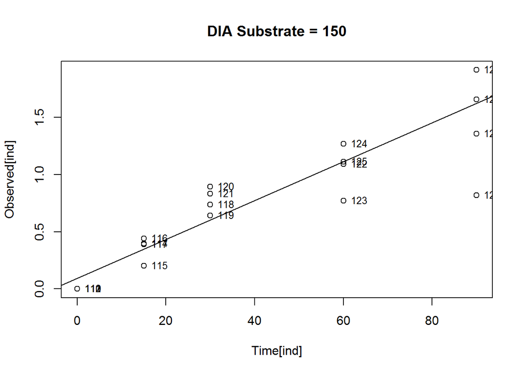

```
## (Intercept)   Time[ind]
##  0.09310748  0.01699426
##             2.5 % 97.5 %
## (Intercept)    NA     NA
## Time[ind]      NA     NA
## [1] "##################################################"
```

```
## 'data.frame':    9 obs. of  2 variables:
##  $ sub: num  50 10 100 75 125 ...
##  $ vel: num  63.2 15.6 37 43.5 74.8 ...
##        sub        vel
## 1  50.0000  63.203351
## 2  10.0000  15.628591
## 3 100.0000  37.017826
## 4  75.0000  43.505515
## 5 125.0000  74.794933
## 6   0.7120   3.987672
## 7   3.1684   6.244342
## 8 250.0000 160.383308
## 9 150.0000  84.971320
```

```
## [1] "here are the rates"
```

```
##
## Model fitted: Michaelis-Menten (2 parms)
##
## Parameter estimates:
##
##               Estimate Std. Error t-value p-value
## d:(Intercept)   5340.7    16494.0  0.3238  0.7556
## e:(Intercept)   8568.7    27021.7  0.3171  0.7604
##
## Residual standard error:
##
##  16.48602 (7 degrees of freedom)
```

```
## No test available
##
##           ModelDf Log lik Df Chisq value p value
##
## DRC model
```

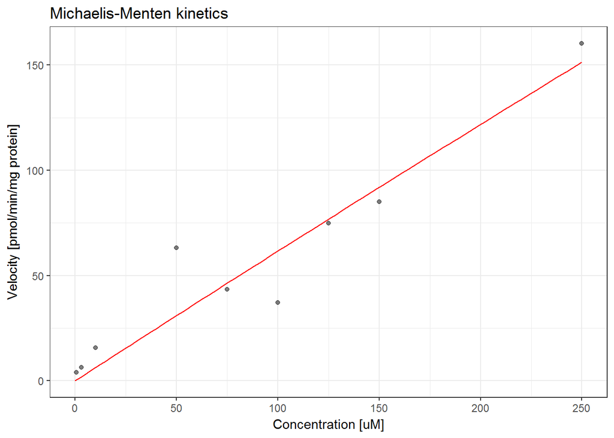

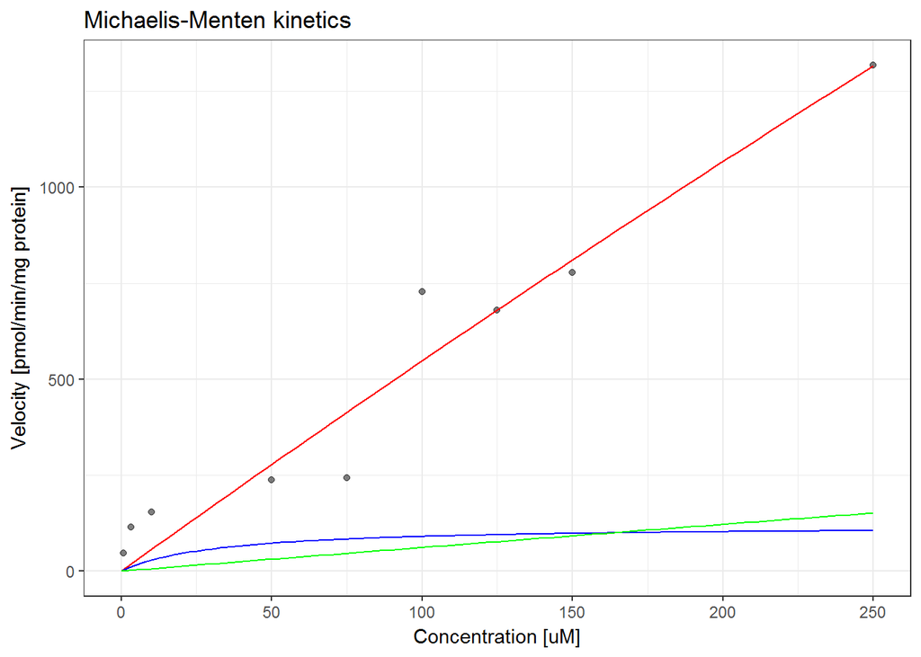

# triadimefon

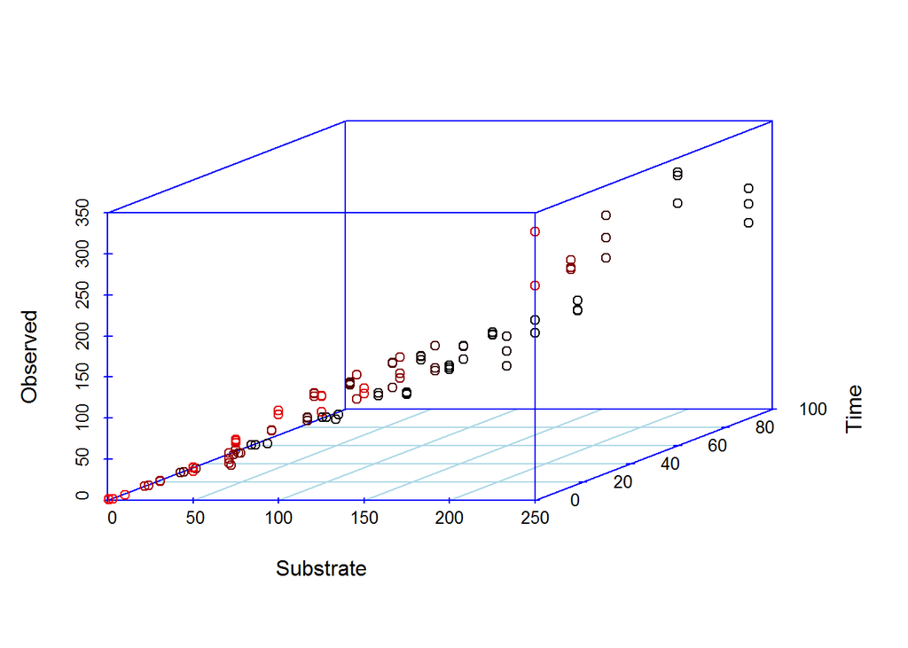

The above figure shows a three-dimensional plot of pesticide substrate concentration, observed concentration and experiment time. We need to condition the pesticide data on the substrate concentrations used in the experiment and regress the observed concentrations over the 90 min period in order to estimate the linear slopes for the Michaelis-Menten kinetic rate constants.

```
## [1] "Substrates:"
```

```
## [1] "##################################################"
## [1] "Substrate =  0.68082"
##  [1] "Indices =  1"  "Indices =  2"  "Indices =  3"  "Indices =  4"
##  [5] "Indices =  5"  "Indices =  6"  "Indices =  7"  "Indices =  8"
##  [9] "Indices =  9"  "Indices =  10" "Indices =  11" "Indices =  12"
## [13] "Indices =  13" "Indices =  14" "Indices =  15"
##  [1] "Times = 0"  "Times = 0"  "Times = 0"  "Times = 15" "Times = 15"
##  [6] "Times = 15" "Times = 30" "Times = 30" "Times = 30" "Times = 60"
## [11] "Times = 60" "Times = 60" "Times = 90" "Times = 90" "Times = 90"
##  [1] "Concs = 1.055195513" "Concs = 1.716416889" "Concs = 1.052273474"
##  [4] "Concs = 0.938633567" "Concs = 0.950248963" "Concs = 0.930818982"
##  [7] "Concs = 0.858111542" "Concs = 0.870265496" "Concs = 0.874485426"
## [10] "Concs = 0.823645984" "Concs = 0.832430656" "Concs = 0.826119617"
## [13] "Concs = 0.817168177" "Concs = 0.817187563" "Concs = 0.816771202"
## Call:
## rlm(formula = Observed[ind] ~ Time[ind])
## Converged in 6 iterations
##
## Coefficients:
##  (Intercept)    Time[ind]
##  0.997266592 -0.002429795
##
## Degrees of freedom: 15 total; 13 residual
## Scale estimate: 0.0572
##
## Call: rlm(formula = Observed[ind] ~ Time[ind])
## Residuals:
##      Min       1Q   Median       3Q      Max
## -0.06626 -0.02892 -0.01905  0.03859  0.71915
##
## Coefficients:
##             Value   Std. Error t value
## (Intercept)  0.9973  0.0210    47.5261
## Time[ind]   -0.0024  0.0004    -5.8645
##
## Residual standard error: 0.05721 on 13 degrees of freedom
```

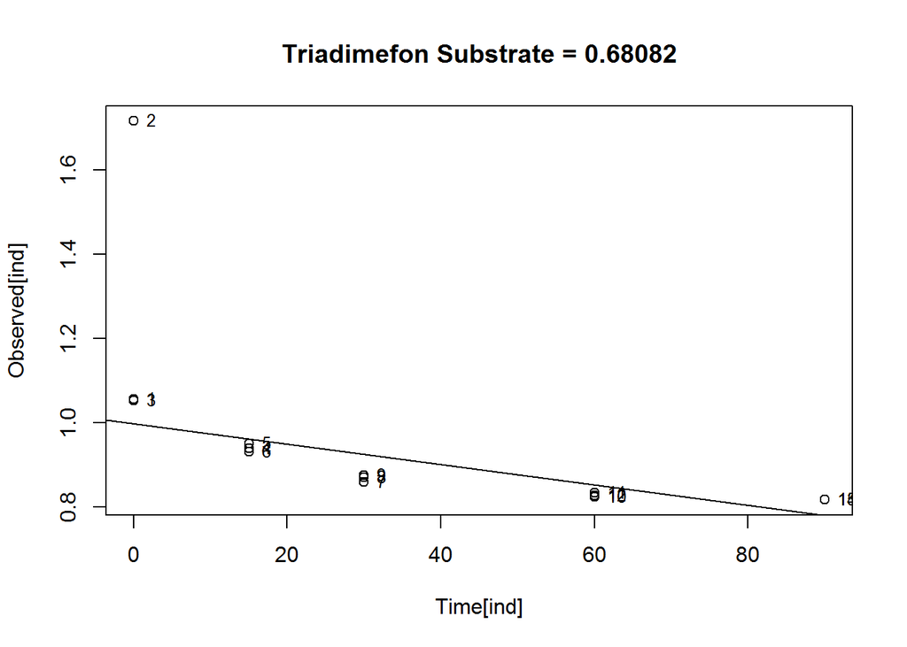

```
##  (Intercept)    Time[ind]
##  0.997266592 -0.002429795
##             2.5 % 97.5 %
## (Intercept)    NA     NA
## Time[ind]      NA     NA
## [1] "##################################################"
## [1] "##################################################"
## [1] "Substrate =  10"
##  [1] "Indices =  16" "Indices =  17" "Indices =  18" "Indices =  19"
##  [5] "Indices =  20" "Indices =  21" "Indices =  22" "Indices =  23"
##  [9] "Indices =  24" "Indices =  25" "Indices =  26" "Indices =  27"
## [13] "Indices =  28" "Indices =  29"
##  [1] "Times = 0"  "Times = 0"  "Times = 0"  "Times = 15" "Times = 15"
##  [6] "Times = 15" "Times = 30" "Times = 30" "Times = 30" "Times = 60"
## [11] "Times = 60" "Times = 90" "Times = 90" "Times = 90"
##  [1] "Concs = 7.075345016" "Concs = 6.990021457" "Concs = 6.934400108"
##  [4] "Concs = 7.582634214" "Concs = 6.195218961" "Concs = 6.437182055"
##  [7] "Concs = 5.377257944" "Concs = 5.321074247" "Concs = 5.115101438"
## [10] "Concs = 2.737595497" "Concs = 2.383571745" "Concs = 4.432786364"
## [13] "Concs = 4.492543529" "Concs = 4.706424998"
## Call:
## rlm(formula = Observed[ind] ~ Time[ind])
## Converged in 7 iterations
##
## Coefficients:
## (Intercept)   Time[ind]
##  6.71631533 -0.03004519
##
## Degrees of freedom: 14 total; 12 residual
## Scale estimate: 0.681
##
## Call: rlm(formula = Observed[ind] ~ Time[ind])
## Residuals:
##     Min      1Q  Median      3Q     Max
## -2.5300 -0.4798  0.1948  0.4052  1.3170
##
## Coefficients:
##             Value   Std. Error t value
## (Intercept)  6.7163  0.3330    20.1663
## Time[ind]   -0.0300  0.0067    -4.5026
##
## Residual standard error: 0.6806 on 12 degrees of freedom
```

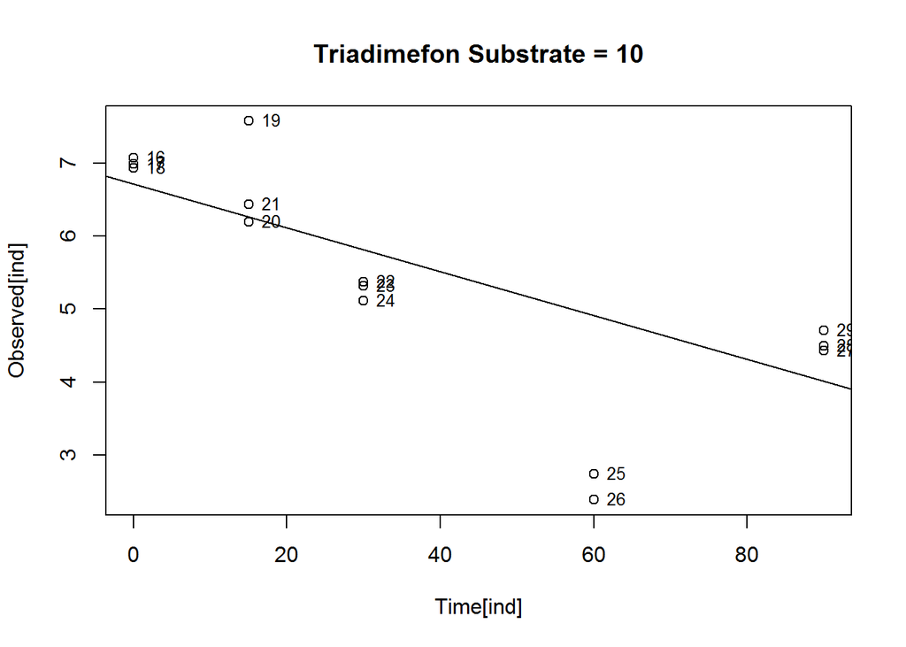

```
## (Intercept)   Time[ind]
##  6.71631533 -0.03004519
##             2.5 % 97.5 %
## (Intercept)    NA     NA
## Time[ind]      NA     NA
## [1] "##################################################"
## [1] "##################################################"
## [1] "Substrate =  2.89"
##  [1] "Indices =  30" "Indices =  31" "Indices =  32" "Indices =  33"
##  [5] "Indices =  34" "Indices =  35" "Indices =  36" "Indices =  37"
##  [9] "Indices =  38" "Indices =  39" "Indices =  40" "Indices =  41"
## [13] "Indices =  42" "Indices =  43"
##  [1] "Times = 0"  "Times = 0"  "Times = 0"  "Times = 15" "Times = 15"
##  [6] "Times = 30" "Times = 30" "Times = 30" "Times = 60" "Times = 60"
## [11] "Times = 60" "Times = 90" "Times = 90" "Times = 90"
##  [1] "Concs = 1.777329525" "Concs = 1.804715957" "Concs = 1.934785731"
##  [4] "Concs = 1.434605415" "Concs = 1.672519857" "Concs = 1.373576496"
##  [7] "Concs = 1.378953779" "Concs = 1.252246261" "Concs = 1.103395037"
## [10] "Concs = 1.073980287" "Concs = 1.03524126"  "Concs = 0.952606695"
## [13] "Concs = 0.896534444" "Concs = 0.898012906"
## Call:
## rlm(formula = Observed[ind] ~ Time[ind])
## Converged in 7 iterations
##
## Coefficients:
##  (Intercept)    Time[ind]
##  1.725759061 -0.009823543
##
## Degrees of freedom: 14 total; 12 residual
## Scale estimate: 0.105
##
## Call: rlm(formula = Observed[ind] ~ Time[ind])
## Residuals:
##      Min       1Q   Median       3Q      Max
## -0.17881 -0.06114  0.00931  0.07331  0.20903
##
## Coefficients:
##             Value   Std. Error t value
## (Intercept)  1.7258  0.0558    30.9211
## Time[ind]   -0.0098  0.0011    -9.2001
##
## Residual standard error: 0.1048 on 12 degrees of freedom
```

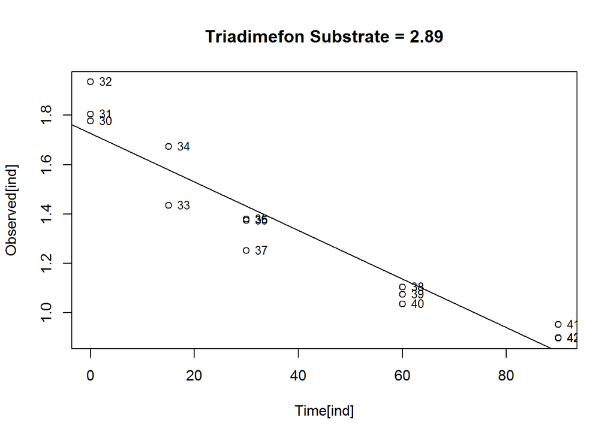

```
##  (Intercept)    Time[ind]
##  1.725759061 -0.009823543
##             2.5 % 97.5 %
## (Intercept)    NA     NA
## Time[ind]      NA     NA
## [1] "##################################################"
## [1] "##################################################"
## [1] "Substrate =  50"
##  [1] "Indices =  44" "Indices =  45" "Indices =  46" "Indices =  47"
##  [5] "Indices =  48" "Indices =  49" "Indices =  50" "Indices =  51"
##  [9] "Indices =  52" "Indices =  53" "Indices =  54" "Indices =  55"
## [13] "Indices =  56" "Indices =  57" "Indices =  58"
##  [1] "Times = 0"  "Times = 0"  "Times = 0"  "Times = 15" "Times = 15"
##  [6] "Times = 15" "Times = 16" "Times = 17" "Times = 18" "Times = 19"
## [11] "Times = 20" "Times = 60" "Times = 90" "Times = 90" "Times = 90"
##  [1] "Concs = 39.44332312" "Concs = 40.07390834" "Concs = 35.6664438"
##  [4] "Concs = 33.26858913" "Concs = 28.71837314" "Concs = 40.88681967"
##  [7] "Concs = 25.24439217" "Concs = 36.71636819" "Concs = 41.57720177"
## [10] "Concs = 36.61330013" "Concs = 35.13544755" "Concs = 31.75029212"
## [13] "Concs = 29.38972896" "Concs = 30.68177634" "Concs = 31.70843431"
## Call:
## rlm(formula = Observed[ind] ~ Time[ind])
## Converged in 6 iterations
##
## Coefficients:
## (Intercept)   Time[ind]
## 37.52823692 -0.08070698
##
## Degrees of freedom: 15 total; 13 residual
## Scale estimate: 2.76
##
## Call: rlm(formula = Observed[ind] ~ Time[ind])
## Residuals:
##      Min       1Q   Median       3Q      Max
## -10.9925  -1.3987   0.4172   1.6795   5.5017
##
## Coefficients:
##             Value   Std. Error t value
## (Intercept) 37.5282  1.2962    28.9531
## Time[ind]   -0.0807  0.0289    -2.7941
##
## Residual standard error: 2.76 on 13 degrees of freedom
```

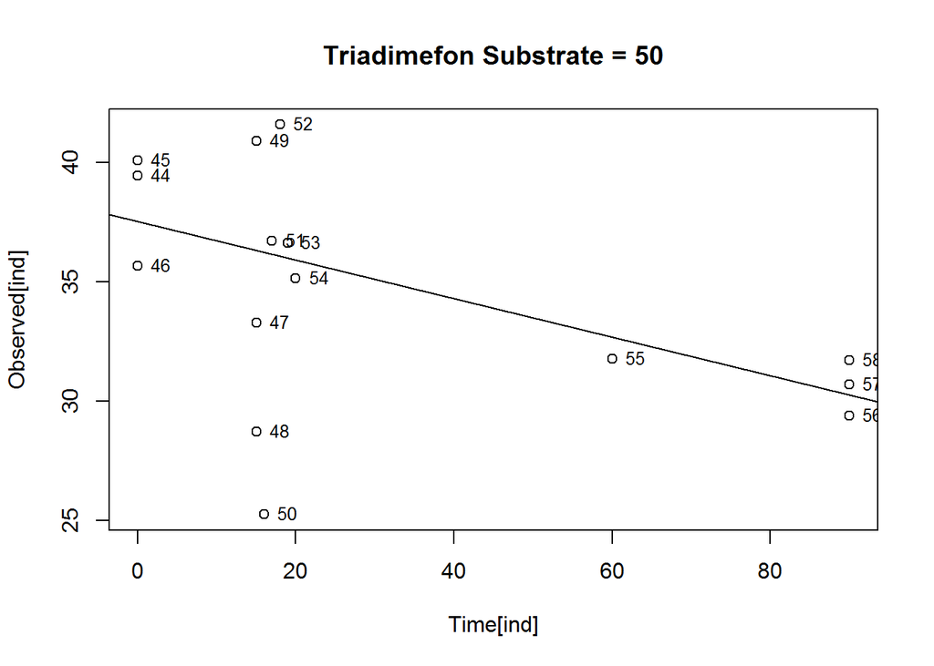

```
## (Intercept)   Time[ind]
## 37.52823692 -0.08070698
##             2.5 % 97.5 %
## (Intercept)    NA     NA
## Time[ind]      NA     NA
## [1] "##################################################"
## [1] "##################################################"
## [1] "Substrate =  75"
##  [1] "Indices =  59" "Indices =  60" "Indices =  61" "Indices =  62"
##  [5] "Indices =  63" "Indices =  64" "Indices =  65" "Indices =  66"
##  [9] "Indices =  67" "Indices =  68" "Indices =  69" "Indices =  70"
## [13] "Indices =  71" "Indices =  72" "Indices =  73"
##  [1] "Times = 0"  "Times = 0"  "Times = 0"  "Times = 15" "Times = 15"
##  [6] "Times = 15" "Times = 30" "Times = 30" "Times = 30" "Times = 60"
## [11] "Times = 60" "Times = 60" "Times = 90" "Times = 90" "Times = 90"
##  [1] "Concs = 73.82935275" "Concs = 69.81459059" "Concs = 72.37204855"
##  [4] "Concs = 67.82074535" "Concs = 68.2563384"  "Concs = 68.54841895"
##  [7] "Concs = 68.13810367" "Concs = 67.01772769" "Concs = 63.94802795"
## [10] "Concs = 64.13247413" "Concs = 63.88083801" "Concs = 60.44713839"
## [13] "Concs = 61.56996061" "Concs = 64.02141502" "Concs = 59.47011182"
## Call:
## rlm(formula = Observed[ind] ~ Time[ind])
## Converged in 4 iterations
##
## Coefficients:
## (Intercept)   Time[ind]
##  70.5414464  -0.1109491
##
## Degrees of freedom: 15 total; 13 residual
## Scale estimate: 1.5
##
## Call: rlm(formula = Observed[ind] ~ Time[ind])
## Residuals:
##     Min      1Q  Median      3Q     Max
## -3.4374 -0.8917 -0.1952  0.9695  3.4654
##
## Coefficients:
##             Value   Std. Error t value
## (Intercept) 70.5414  0.8050    87.6250
## Time[ind]   -0.1109  0.0159    -6.9799
##
## Residual standard error: 1.503 on 13 degrees of freedom
```

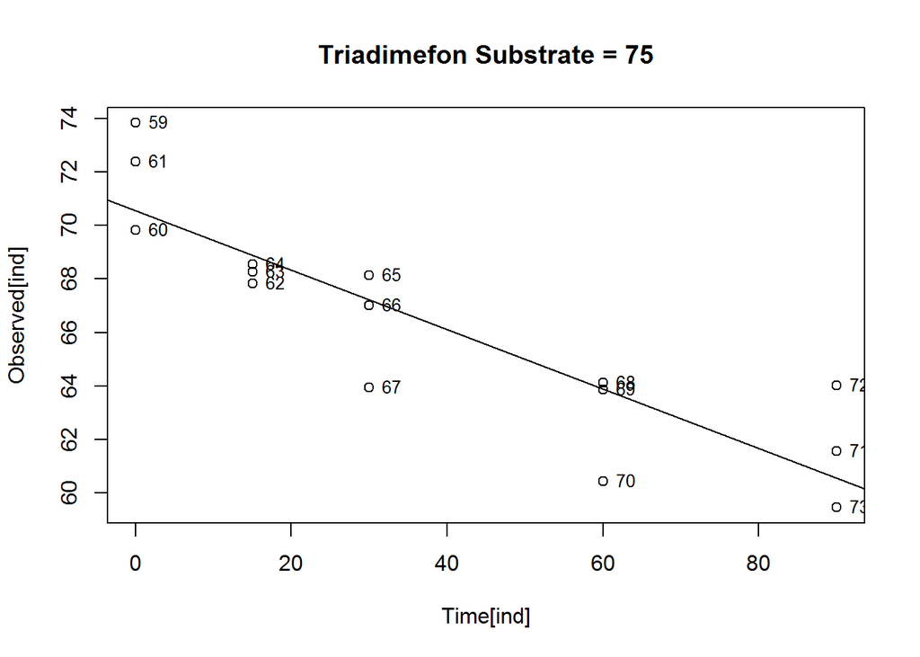

```
## (Intercept)   Time[ind]
##  70.5414464  -0.1109491
##             2.5 % 97.5 %
## (Intercept)    NA     NA
## Time[ind]      NA     NA
## [1] "##################################################"
## [1] "##################################################"
## [1] "Substrate =  100"
##  [1] "Indices =  74" "Indices =  75" "Indices =  76" "Indices =  77"
##  [5] "Indices =  78" "Indices =  79" "Indices =  80" "Indices =  81"
##  [9] "Indices =  82" "Indices =  83" "Indices =  84" "Indices =  85"
## [13] "Indices =  86" "Indices =  87" "Indices =  88"
##  [1] "Times = 0"  "Times = 0"  "Times = 0"  "Times = 15" "Times = 15"
##  [6] "Times = 15" "Times = 30" "Times = 30" "Times = 30" "Times = 60"
## [11] "Times = 60" "Times = 60" "Times = 90" "Times = 90" "Times = 90"
##  [1] "Concs = 109.3199937" "Concs = 104.4849272" "Concs = 109.1666963"
##  [4] "Concs = 109.8399004" "Concs = 113.5827498" "Concs = 114.1444056"
##  [7] "Concs = 110.3922061" "Concs = 107.3962739" "Concs = 108.8977191"
## [10] "Concs = 108.1725461" "Concs = 104.4949296" "Concs = 109.1134227"
## [13] "Concs = 104.4988435" "Concs = 100.9234253" "Concs = 101.7288349"
## Call:
## rlm(formula = Observed[ind] ~ Time[ind])
## Converged in 6 iterations
##
## Coefficients:
##  (Intercept)    Time[ind]
## 111.19791229  -0.08429047
##
## Degrees of freedom: 15 total; 13 residual
## Scale estimate: 2.79
##
## Call: rlm(formula = Observed[ind] ~ Time[ind])
## Residuals:
##      Min       1Q   Median       3Q      Max
## -6.71299 -1.88043 -0.09365  1.87753  4.21085
##
## Coefficients:
##             Value    Std. Error t value
## (Intercept) 111.1979   1.1916    93.3145
## Time[ind]    -0.0843   0.0235    -3.5824
##
## Residual standard error: 2.792 on 13 degrees of freedom
```

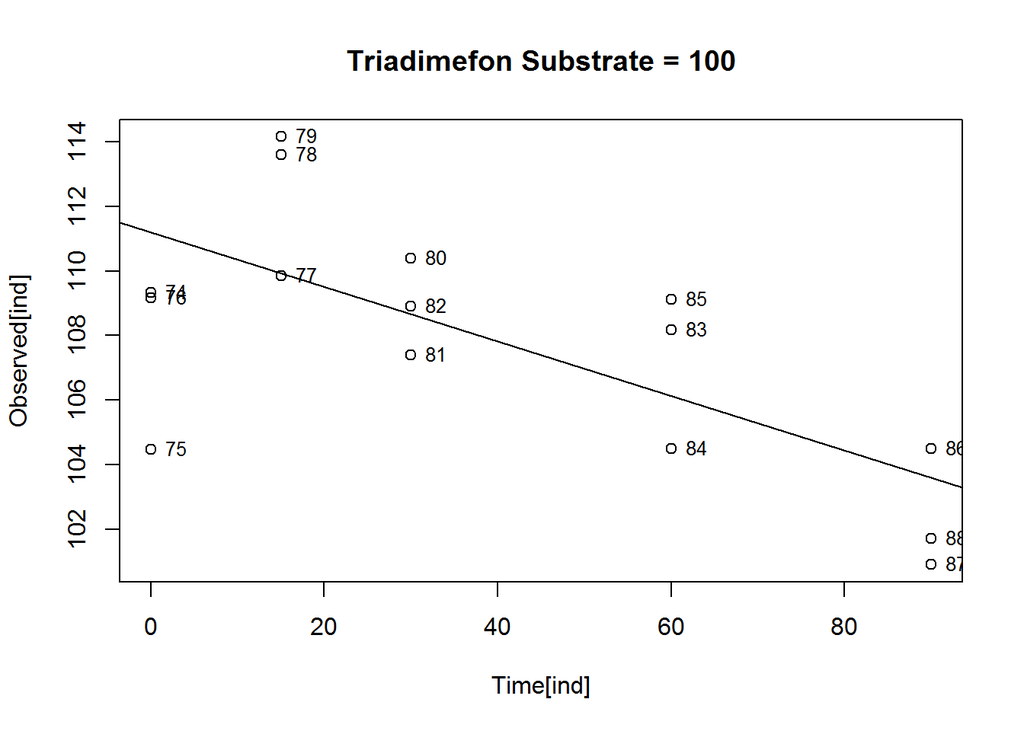

```
##  (Intercept)    Time[ind]
## 111.19791229  -0.08429047
##             2.5 % 97.5 %
## (Intercept)    NA     NA
## Time[ind]      NA     NA
## [1] "##################################################"
## [1] "##################################################"
## [1] "Substrate =  125"
##  [1] "Indices =  89"  "Indices =  90"  "Indices =  91"  "Indices =  92"
##  [5] "Indices =  93"  "Indices =  94"  "Indices =  95"  "Indices =  96"
##  [9] "Indices =  97"  "Indices =  98"  "Indices =  99"  "Indices =  100"
## [13] "Indices =  101" "Indices =  102" "Indices =  103"
##  [1] "Times = 0"  "Times = 0"  "Times = 0"  "Times = 15" "Times = 15"
##  [6] "Times = 15" "Times = 30" "Times = 30" "Times = 30" "Times = 60"
## [11] "Times = 60" "Times = 60" "Times = 90" "Times = 90" "Times = 90"
##  [1] "Concs = 107.5365248" "Concs = 127.5663033" "Concs = 126.8308018"
##  [4] "Concs = 106.5228047" "Concs = 135.7677165" "Concs = 106.6195125"
##  [7] "Concs = 103.9682822" "Concs = 133.2578786" "Concs = 134.0194733"
## [10] "Concs = 105.1755811" "Concs = 121.0935634" "Concs = 120.6467177"
## [13] "Concs = 103.405648"  "Concs = 103.7554597" "Concs = 119.5785281"
## Call:
## rlm(formula = Observed[ind] ~ Time[ind])
## Converged in 1 iterations
##
## Coefficients:
## (Intercept)   Time[ind]
## 121.7354023  -0.1201474
##
## Degrees of freedom: 15 total; 13 residual
## Scale estimate: 13.9
##
## Call: rlm(formula = Observed[ind] ~ Time[ind])
## Residuals:
##     Min      1Q  Median      3Q     Max
## -14.199 -11.332   5.095   7.612  15.888
##
## Coefficients:
##             Value    Std. Error t value
## (Intercept) 121.7354   4.8954    24.8673
## Time[ind]    -0.1201   0.0967    -1.2430
##
## Residual standard error: 13.86 on 13 degrees of freedom
```

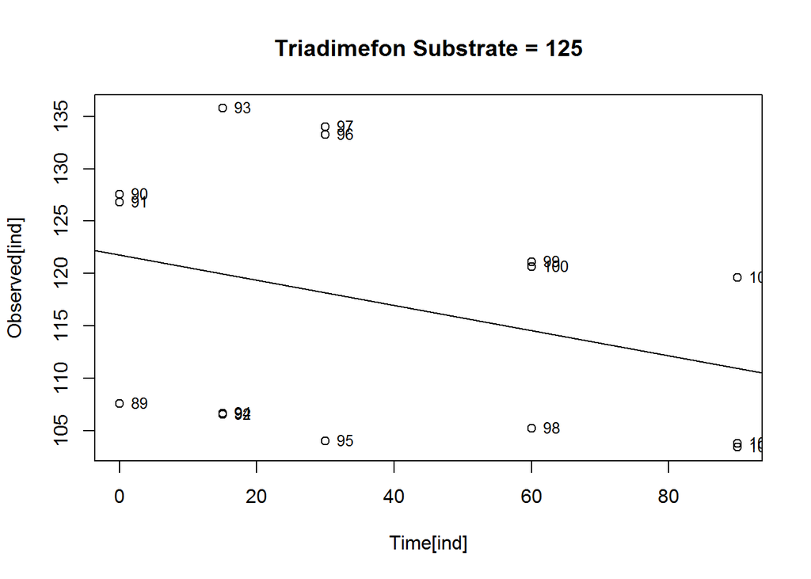

```
## (Intercept)   Time[ind]
## 121.7354023  -0.1201474
##             2.5 % 97.5 %
## (Intercept)    NA     NA
## Time[ind]      NA     NA
## [1] "##################################################"
## [1] "##################################################"
## [1] "Substrate =  150"
##  [1] "Indices =  104" "Indices =  105" "Indices =  106" "Indices =  107"
##  [5] "Indices =  108" "Indices =  109" "Indices =  110" "Indices =  111"
##  [9] "Indices =  112" "Indices =  113" "Indices =  114" "Indices =  115"
## [13] "Indices =  116" "Indices =  117" "Indices =  118"
##  [1] "Times = 0"  "Times = 0"  "Times = 0"  "Times = 15" "Times = 15"
##  [6] "Times = 15" "Times = 30" "Times = 30" "Times = 30" "Times = 60"
## [11] "Times = 60" "Times = 60" "Times = 90" "Times = 90" "Times = 90"
##  [1] "Concs = 136.4221117" "Concs = 136.379058"  "Concs = 129.4961115"
##  [4] "Concs = 137.8091818" "Concs = 131.9793127" "Concs = 157.7963414"
##  [7] "Concs = 124.5114441" "Concs = 127.6369723" "Concs = 154.8965192"
## [10] "Concs = 132.7699361" "Concs = 97.16035365" "Concs = 114.5318893"
## [13] "Concs = 131.7957906" "Concs = 143.1419758" "Concs = 131.1273703"
## Call:
## rlm(formula = Observed[ind] ~ Time[ind])
## Converged in 8 iterations
##
## Coefficients:
##  (Intercept)    Time[ind]
## 134.44160061  -0.04431801
##
## Degrees of freedom: 15 total; 13 residual
## Scale estimate: 7.33
##
## Call: rlm(formula = Observed[ind] ~ Time[ind])
## Residuals:
##      Min       1Q   Median       3Q      Max
## -34.6222  -5.2103   0.9874   3.0064  24.0195
##
## Coefficients:
##             Value    Std. Error t value
## (Intercept) 134.4416   4.5823    29.3391
## Time[ind]    -0.0443   0.0905    -0.4898
##
## Residual standard error: 7.333 on 13 degrees of freedom
```

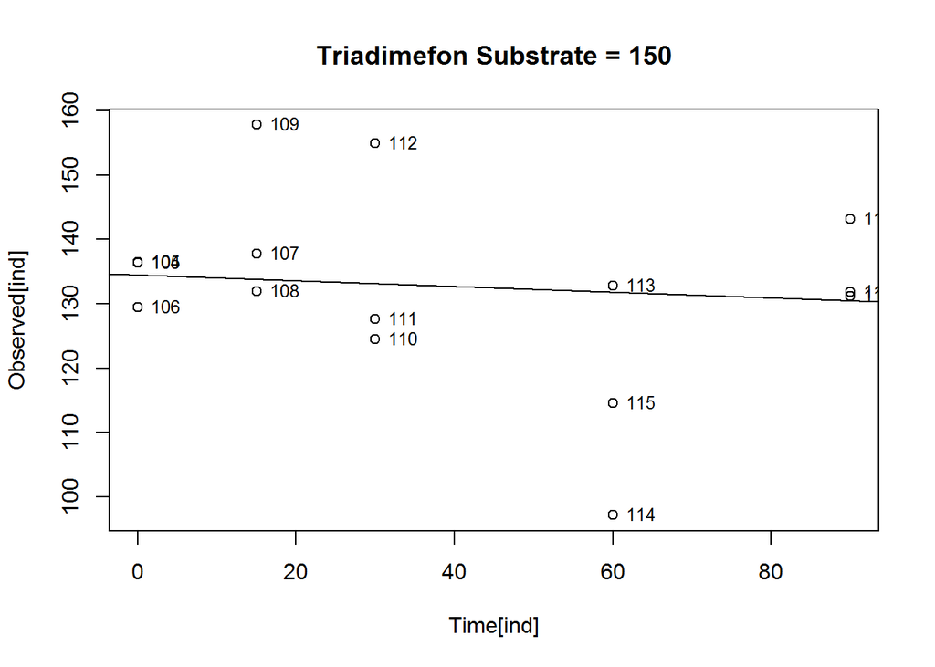

```
##  (Intercept)    Time[ind]
## 134.44160061  -0.04431801
##             2.5 % 97.5 %
## (Intercept)    NA     NA
## Time[ind]      NA     NA
## [1] "##################################################"
## [1] "##################################################"
## [1] "Substrate =  250"
##  [1] "Indices =  119" "Indices =  120" "Indices =  121" "Indices =  122"
##  [5] "Indices =  123" "Indices =  124" "Indices =  125" "Indices =  126"
##  [9] "Indices =  127" "Indices =  128" "Indices =  129" "Indices =  130"
## [13] "Indices =  131" "Indices =  132"
##  [1] "Times = 0"  "Times = 0"  "Times = 15" "Times = 15" "Times = 15"
##  [6] "Times = 30" "Times = 30" "Times = 30" "Times = 60" "Times = 60"
## [11] "Times = 60" "Times = 90" "Times = 90" "Times = 90"
##  [1] "Concs = 261.549615"  "Concs = 326.9796946" "Concs = 266.8345989"
##  [4] "Concs = 264.2922486" "Concs = 275.5322522" "Concs = 261.2512151"
##  [7] "Concs = 285.8702782" "Concs = 313.1209636" "Concs = 328.5136848"
## [10] "Concs = 332.5575402" "Concs = 294.3280544" "Concs = 278.96352"
## [13] "Concs = 237.618938"  "Concs = 260.2516169"
## Call:
## rlm(formula = Observed[ind] ~ Time[ind])
## Converged in 4 iterations
##
## Coefficients:
## (Intercept)   Time[ind]
## 289.2108635  -0.1081183
##
## Degrees of freedom: 14 total; 12 residual
## Scale estimate: 35.6
##
## Call: rlm(formula = Observed[ind] ~ Time[ind])
## Residuals:
##     Min      1Q  Median      3Q     Max
## -41.861 -22.661  -6.287  23.266  49.834
##
## Coefficients:
##             Value    Std. Error t value
## (Intercept) 289.2109  14.8017    19.5390
## Time[ind]    -0.1081   0.2823    -0.3829
##
## Residual standard error: 35.59 on 12 degrees of freedom
```

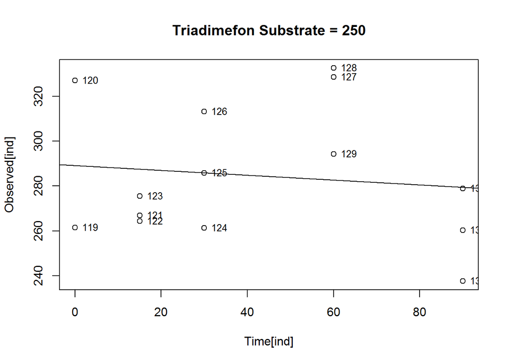

```
## (Intercept)   Time[ind]
## 289.2108635  -0.1081183
##             2.5 % 97.5 %
## (Intercept)    NA     NA
## Time[ind]      NA     NA
## [1] "##################################################"
```

```
## 'data.frame':    9 obs. of  2 variables:
##  $ sub: num  0.681 10 2.89 50 75 ...
##  $ vel: num  12.1 150.2 49.1 403.5 554.7 ...
##         sub       vel
## 1   0.68082  12.14897
## 2  10.00000 150.22595
## 3   2.89000  49.11772
## 4  50.00000 403.53491
## 5  75.00000 554.74564
## 6 100.00000 421.45233
## 7 125.00000 600.73708
## 8 150.00000 221.59003
## 9 250.00000 540.59158
```

```
## [1] "here are the rates"
```

```
##
## Model fitted: Michaelis-Menten (2 parms)
##
## Parameter estimates:
##
##               Estimate Std. Error t-value   p-value
## d:(Intercept)  534.106     92.306  5.7863 0.0006729 ***
## e:(Intercept)   18.379     15.312  1.2003 0.2690493
## ---
## Signif. codes:  0 '***' 0.001 '**' 0.01 '*' 0.05 '.' 0.1 ' ' 1
##
## Residual standard error:
##
##  121.6792 (7 degrees of freedom)
```

```
## No test available
##
##           ModelDf Log lik Df Chisq value p value
##
## DRC model
```

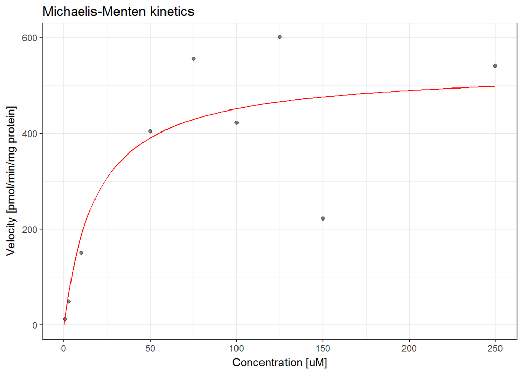

# tdla

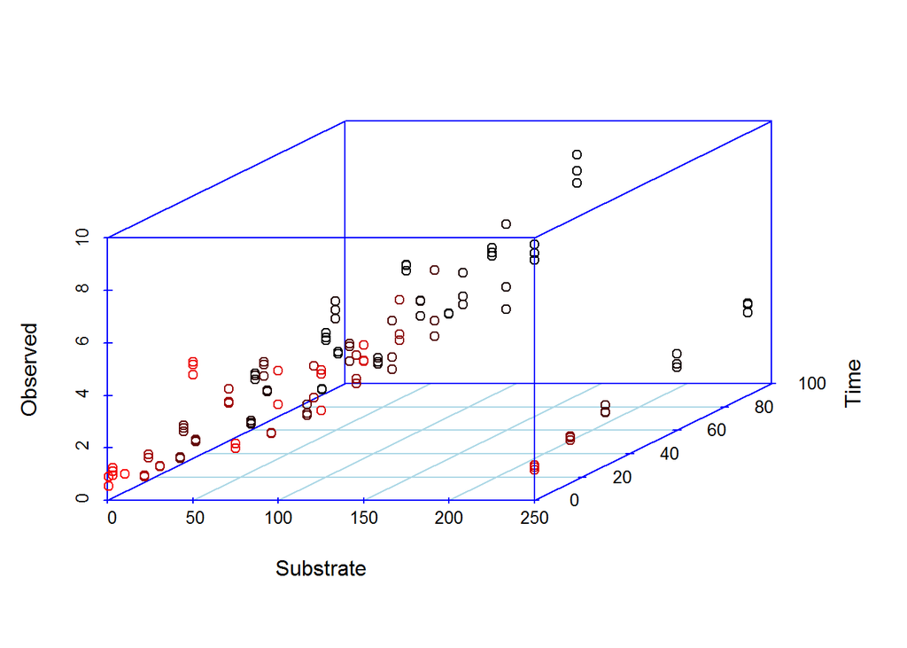

The above figure shows a three-dimensional plot of pesticide substrate concentration, observed concentration and experiment time. We need to condition the pesticide data on the substrate concentrations used in the experiment and regress the observed concentrations over the 90 min period in order to estimate the linear slopes for the Michaelis-Menten kinetic rate constants.

```
## [1] "Substrates:"
```

```
## [1] "##################################################"
## [1] "Substrate =  0.68"
##  [1] "Indices =  1"  "Indices =  2"  "Indices =  3"  "Indices =  4"
##  [5] "Indices =  5"  "Indices =  6"  "Indices =  7"  "Indices =  8"
##  [9] "Indices =  9"  "Indices =  10" "Indices =  11" "Indices =  12"
## [13] "Indices =  13" "Indices =  14"
##  [1] "Times = 0"  "Times = 0"  "Times = 15" "Times = 15" "Times = 15"
##  [6] "Times = 30" "Times = 30" "Times = 30" "Times = 60" "Times = 60"
## [11] "Times = 60" "Times = 90" "Times = 90" "Times = 90"
##  [1] "Concs = 0.911333779" "Concs = 0.538623139" "Concs = 0.274067068"
##  [4] "Concs = 0.295482796" "Concs = 0.240279185" "Concs = 0.257746875"
##  [7] "Concs = 0.308331891" "Concs = 0.308676715" "Concs = 0.25011887"
## [10] "Concs = 0.37258778"  "Concs = 0.288696798" "Concs = 0.223412134"
## [13] "Concs = 0.250234863" "Concs = 0.212692933"
## Call:
## rlm(formula = Observed[ind] ~ Time[ind])
## Converged in 13 iterations
##
## Coefficients:
## (Intercept)   Time[ind]
##  0.33336175 -0.00112991
##
## Degrees of freedom: 14 total; 12 residual
## Scale estimate: 0.0327
##
## Call: rlm(formula = Observed[ind] ~ Time[ind])
## Residuals:
##        Min         1Q     Median         3Q        Max
## -0.0761339 -0.0204420  0.0003049  0.0219885  0.5779720
##
## Coefficients:
##             Value   Std. Error t value
## (Intercept)  0.3334  0.0220    15.1640
## Time[ind]   -0.0011  0.0004    -2.6944
##
## Residual standard error: 0.03267 on 12 degrees of freedom
```

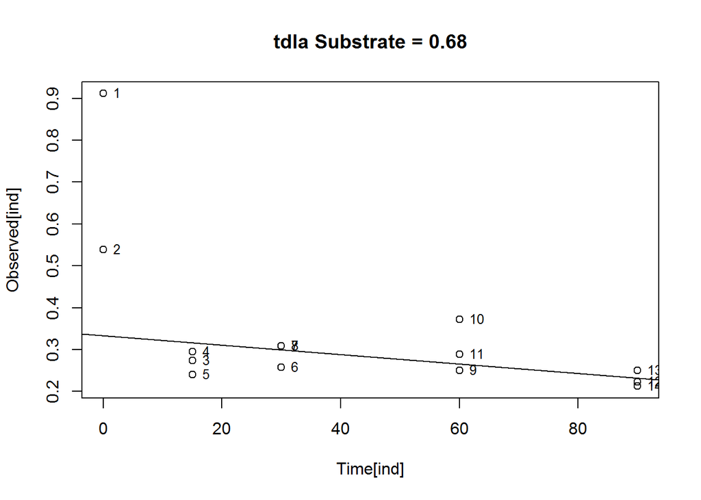

```
## (Intercept)   Time[ind]
##  0.33336175 -0.00112991
##             2.5 % 97.5 %
## (Intercept)    NA     NA
## Time[ind]      NA     NA
## [1] "##################################################"
## [1] "##################################################"
## [1] "Substrate =  10"
##  [1] "Indices =  15" "Indices =  16" "Indices =  17" "Indices =  18"
##  [5] "Indices =  19" "Indices =  20" "Indices =  21" "Indices =  22"
##  [9] "Indices =  23" "Indices =  24" "Indices =  25" "Indices =  26"
## [13] "Indices =  27" "Indices =  28"
##  [1] "Times = 0"  "Times = 0"  "Times = 0"  "Times = 15" "Times = 15"
##  [6] "Times = 15" "Times = 30" "Times = 30" "Times = 30" "Times = 60"
## [11] "Times = 60" "Times = 90" "Times = 90" "Times = 90"
##  [1] "Concs = 1.018010717" "Concs = 1.006352529" "Concs = 1.006022683"
##  [4] "Concs = 0.656082156" "Concs = 0.613384138" "Concs = 0.648345515"
##  [7] "Concs = 0.97315514"  "Concs = 0.957123696" "Concs = 0.919138229"
## [10] "Concs = 1.467786187" "Concs = 1.525372593" "Concs = 1.652830116"
## [13] "Concs = 1.583931982" "Concs = 1.587496374"
## Call:
## rlm(formula = Observed[ind] ~ Time[ind])
## Converged in 1 iterations
##
## Coefficients:
## (Intercept)   Time[ind]
## 0.763609368 0.009380002
##
## Degrees of freedom: 14 total; 12 residual
## Scale estimate: 0.252
##
## Call: rlm(formula = Observed[ind] ~ Time[ind])
## Residuals:
##     Min      1Q  Median      3Q     Max
## -0.2909 -0.1164 -0.0221  0.1846  0.2544
##
## Coefficients:
##             Value  Std. Error t value
## (Intercept) 0.7636 0.0815     9.3739
## Time[ind]   0.0094 0.0016     5.7470
##
## Residual standard error: 0.2523 on 12 degrees of freedom
```

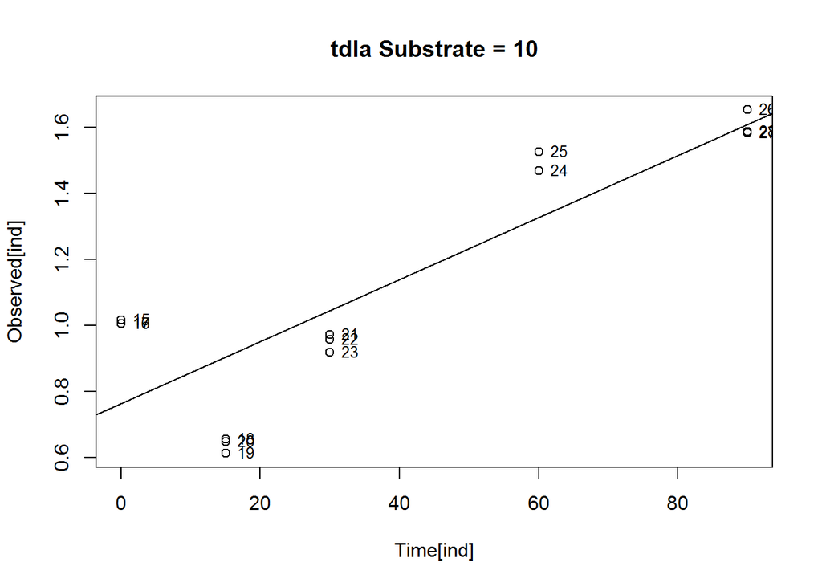

```
## (Intercept)   Time[ind]
## 0.763609368 0.009380002
##             2.5 % 97.5 %
## (Intercept)    NA     NA
## Time[ind]      NA     NA
## [1] "##################################################"
## [1] "##################################################"
## [1] "Substrate =  2.89"
##  [1] "Indices =  29" "Indices =  30" "Indices =  31" "Indices =  32"
##  [5] "Indices =  33" "Indices =  34" "Indices =  35" "Indices =  36"
##  [9] "Indices =  37" "Indices =  38" "Indices =  39" "Indices =  40"
## [13] "Indices =  41" "Indices =  42"
##  [1] "Times = 0"  "Times = 0"  "Times = 0"  "Times = 15" "Times = 15"
##  [6] "Times = 30" "Times = 30" "Times = 30" "Times = 60" "Times = 60"
## [11] "Times = 60" "Times = 90" "Times = 90" "Times = 90"
##  [1] "Concs = 0.967608564" "Concs = 1.104071328" "Concs = 1.232020771"
##  [4] "Concs = 1.089981806" "Concs = 0.962740371" "Concs = 1.30210336"
##  [7] "Concs = 1.429231051" "Concs = 1.521298076" "Concs = 2.093039311"
## [10] "Concs = 2.181520068" "Concs = 1.944692162" "Concs = 2.111347812"
## [13] "Concs = 2.37727648"  "Concs = 2.200482444"
## Call:
## rlm(formula = Observed[ind] ~ Time[ind])
## Converged in 4 iterations
##
## Coefficients:
## (Intercept)   Time[ind]
##  1.02311637  0.01433486
##
## Degrees of freedom: 14 total; 12 residual
## Scale estimate: 0.193
##
## Call: rlm(formula = Observed[ind] ~ Time[ind])
## Residuals:
##      Min       1Q   Median       3Q      Max
## -0.27540 -0.13931  0.01878  0.07775  0.29831
##
## Coefficients:
##             Value   Std. Error t value
## (Intercept)  1.0231  0.0863    11.8493
## Time[ind]    0.0143  0.0017     8.6778
##
## Residual standard error: 0.1934 on 12 degrees of freedom
```

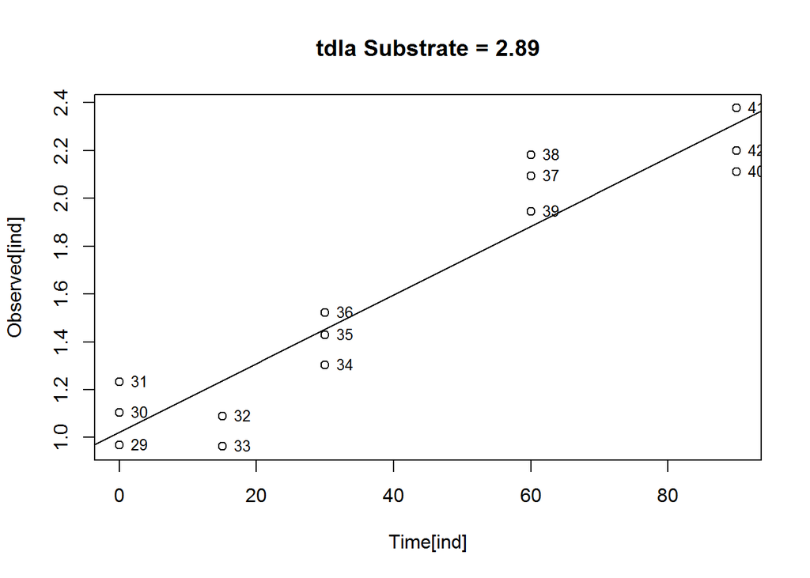

```
## (Intercept)   Time[ind]
##  1.02311637  0.01433486
##             2.5 % 97.5 %
## (Intercept)    NA     NA
## Time[ind]      NA     NA
## [1] "##################################################"
## [1] "##################################################"
## [1] "Substrate =  50"
##  [1] "Indices =  43" "Indices =  44" "Indices =  45" "Indices =  46"
##  [5] "Indices =  47" "Indices =  48" "Indices =  49" "Indices =  50"
##  [9] "Indices =  51" "Indices =  52" "Indices =  53" "Indices =  54"
## [13] "Indices =  55" "Indices =  56" "Indices =  57"
##  [1] "Times = 0"  "Times = 0"  "Times = 0"  "Times = 15" "Times = 15"
##  [6] "Times = 15" "Times = 30" "Times = 30" "Times = 30" "Times = 60"
## [11] "Times = 60" "Times = 60" "Times = 90" "Times = 90" "Times = 90"
##  [1] "Concs = 5.183692755" "Concs = 5.288137946" "Concs = 4.784272534"
##  [4] "Concs = 3.082573879" "Concs = 3.042434157" "Concs = 3.580371528"
##  [7] "Concs = 3.391053517" "Concs = 3.946105993" "Concs = 3.834987724"
## [10] "Concs = 4.261556467" "Concs = 4.914986114" "Concs = 4.584590488"
## [13] "Concs = 4.976952649" "Concs = 4.746707742" "Concs = 4.95610163"
## Call:
## rlm(formula = Observed[ind] ~ Time[ind])
## Converged in 9 iterations
##
## Coefficients:
## (Intercept)   Time[ind]
## 3.924377589 0.008666301
##
## Degrees of freedom: 15 total; 13 residual
## Scale estimate: 0.698
##
## Call: rlm(formula = Observed[ind] ~ Time[ind])
## Residuals:
##      Min       1Q   Median       3Q      Max
## -1.01194 -0.41169  0.04236  0.37162  1.36376
##
## Coefficients:
##             Value   Std. Error t value
## (Intercept)  3.9244  0.3847    10.2005
## Time[ind]    0.0087  0.0076     1.1409
##
## Residual standard error: 0.6977 on 13 degrees of freedom
```

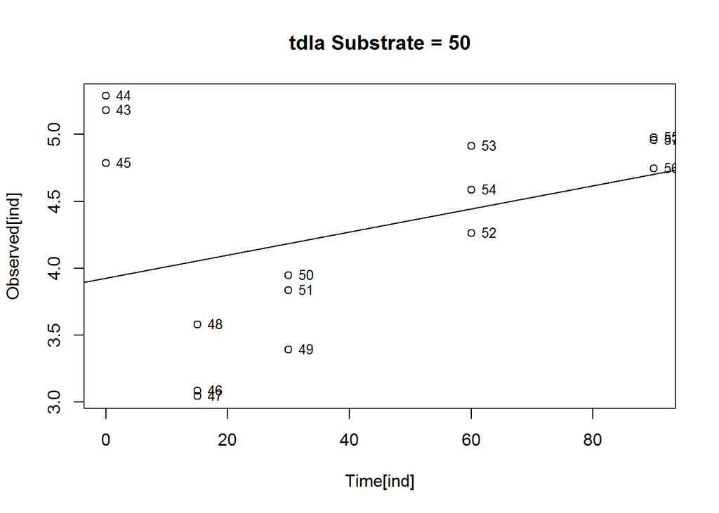

```
## (Intercept)   Time[ind]
## 3.924377589 0.008666301
##             2.5 % 97.5 %
## (Intercept)    NA     NA
## Time[ind]      NA     NA
## [1] "##################################################"
## [1] "##################################################"
## [1] "Substrate =  75"
##  [1] "Indices =  58" "Indices =  59" "Indices =  60" "Indices =  61"
##  [5] "Indices =  62" "Indices =  63" "Indices =  64" "Indices =  65"
##  [9] "Indices =  66" "Indices =  67" "Indices =  68" "Indices =  69"
## [13] "Indices =  70" "Indices =  71" "Indices =  72"
##  [1] "Times = 0"  "Times = 0"  "Times = 0"  "Times = 15" "Times = 15"
##  [6] "Times = 15" "Times = 30" "Times = 30" "Times = 30" "Times = 60"
## [11] "Times = 60" "Times = 60" "Times = 90" "Times = 90" "Times = 90"
##  [1] "Concs = 2.156819763" "Concs = 1.976073713" "Concs = 2.164685233"
##  [4] "Concs = 1.915486338" "Concs = 1.871421816" "Concs = 1.904115966"
##  [7] "Concs = 2.323880269" "Concs = 1.922349719" "Concs = 1.984507804"
## [10] "Concs = 2.756656604" "Concs = 2.61971313"  "Concs = 2.531743911"
## [13] "Concs = 3.126097153" "Concs = 3.090615235" "Concs = 3.137674604"
## Call:
## rlm(formula = Observed[ind] ~ Time[ind])
## Converged in 11 iterations
##
## Coefficients:
## (Intercept)   Time[ind]
##  1.83645163  0.01343346
##
## Degrees of freedom: 15 total; 13 residual
## Scale estimate: 0.182
##
## Call: rlm(formula = Observed[ind] ~ Time[ind])
## Residuals:
##      Min       1Q   Median       3Q      Max
## -0.31711 -0.12815  0.04515  0.10320  0.32823
##
## Coefficients:
##             Value   Std. Error t value
## (Intercept)  1.8365  0.0978    18.7822
## Time[ind]    0.0134  0.0019     6.9582
##
## Residual standard error: 0.1816 on 13 degrees of freedom
```

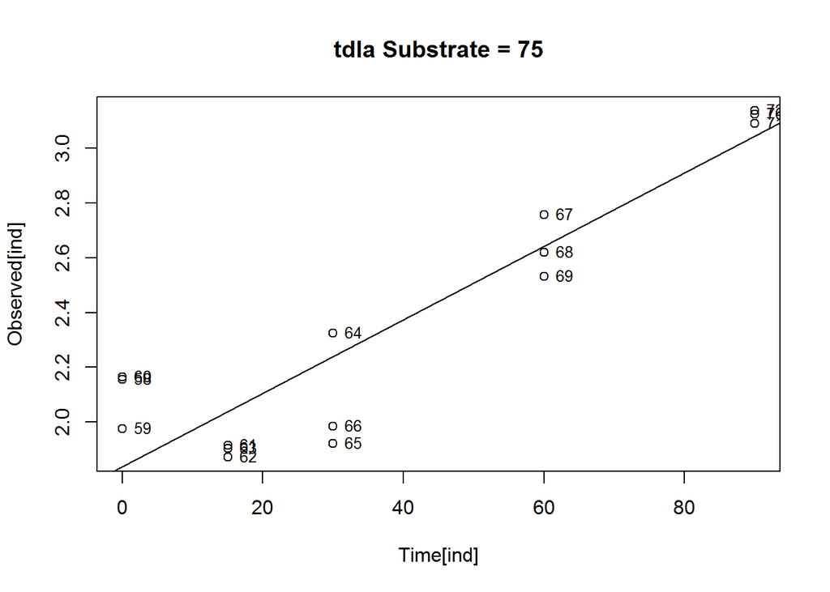

```
## (Intercept)   Time[ind]
##  1.83645163  0.01343346
##             2.5 % 97.5 %
## (Intercept)    NA     NA
## Time[ind]      NA     NA
## [1] "##################################################"
## [1] "##################################################"
## [1] "Substrate =  100"
##  [1] "Indices =  73" "Indices =  74" "Indices =  75" "Indices =  76"
##  [5] "Indices =  77" "Indices =  78" "Indices =  79" "Indices =  80"
##  [9] "Indices =  81" "Indices =  82" "Indices =  83" "Indices =  84"
## [13] "Indices =  85"
##  [1] "Times = 0"  "Times = 0"  "Times = 15" "Times = 15" "Times = 30"
##  [6] "Times = 30" "Times = 30" "Times = 60" "Times = 60" "Times = 60"
## [11] "Times = 90" "Times = 90" "Times = 90"
##  [1] "Concs = 3.665038064" "Concs = 4.929996704" "Concs = 3.247700116"
##  [4] "Concs = 4.448925817" "Concs = 3.964352006" "Concs = 4.642993841"
##  [7] "Concs = 4.543916406" "Concs = 4.365953811" "Concs = 4.91659626"
## [10] "Concs = 4.946841298" "Concs = 5.323415111" "Concs = 5.610391673"
## [13] "Concs = 5.447082915"
## Call:
## rlm(formula = Observed[ind] ~ Time[ind])
## Converged in 8 iterations
##
## Coefficients:
## (Intercept)   Time[ind]
##  3.88781862  0.01646824
##
## Degrees of freedom: 13 total; 11 residual
## Scale estimate: 0.357
##
## Call: rlm(formula = Observed[ind] ~ Time[ind])
## Residuals:
##      Min       1Q   Median       3Q      Max
## -0.88714 -0.22278  0.07093  0.24043  1.04218
##
## Coefficients:
##             Value   Std. Error t value
## (Intercept)  3.8878  0.2106    18.4628
## Time[ind]    0.0165  0.0039     4.2421
##
## Residual standard error: 0.3565 on 11 degrees of freedom
```

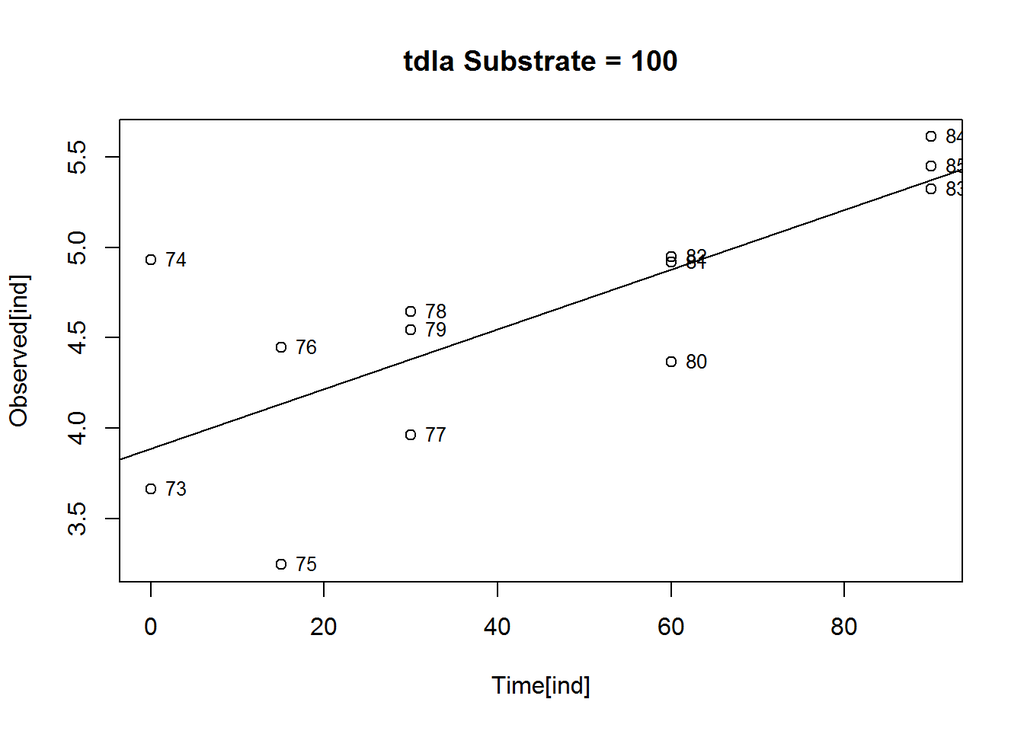

```
## (Intercept)   Time[ind]
##  3.88781862  0.01646824
##             2.5 % 97.5 %
## (Intercept)    NA     NA
## Time[ind]      NA     NA
## [1] "##################################################"
## [1] "##################################################"
## [1] "Substrate =  125"
##  [1] "Indices =  86"  "Indices =  87"  "Indices =  88"  "Indices =  89"
##  [5] "Indices =  90"  "Indices =  91"  "Indices =  92"  "Indices =  93"
##  [9] "Indices =  94"  "Indices =  95"  "Indices =  96"  "Indices =  97"
## [13] "Indices =  98"  "Indices =  99"  "Indices =  100"
##  [1] "Times = 0"  "Times = 0"  "Times = 0"  "Times = 15" "Times = 15"
##  [6] "Times = 15" "Times = 30" "Times = 30" "Times = 30" "Times = 60"
## [11] "Times = 60" "Times = 60" "Times = 90" "Times = 90" "Times = 90"
##  [1] "Concs = 3.435420024" "Concs = 4.97730785"  "Concs = 4.825739914"
##  [4] "Concs = 3.975016459" "Concs = 4.864396394" "Concs = 3.779106429"
##  [7] "Concs = 4.123881939" "Concs = 3.650943656" "Concs = 5.50644677"
## [10] "Concs = 4.807257346" "Concs = 6.000486305" "Concs = 5.098368211"
## [13] "Concs = 5.156782065" "Concs = 5.738264141" "Concs = 5.42544885"
## Call:
## rlm(formula = Observed[ind] ~ Time[ind])
## Converged in 1 iterations
##
## Coefficients:
## (Intercept)   Time[ind]
##  4.19059517  0.01454007
##
## Degrees of freedom: 15 total; 13 residual
## Scale estimate: 0.746
##
## Call: rlm(formula = Observed[ind] ~ Time[ind])
## Residuals:
##      Min       1Q   Median       3Q      Max
## -0.97585 -0.46830 -0.07375  0.54542  0.93749
##
## Coefficients:
##             Value   Std. Error t value
## (Intercept)  4.1906  0.2630    15.9349
## Time[ind]    0.0145  0.0052     2.8002
##
## Residual standard error: 0.7456 on 13 degrees of freedom
```

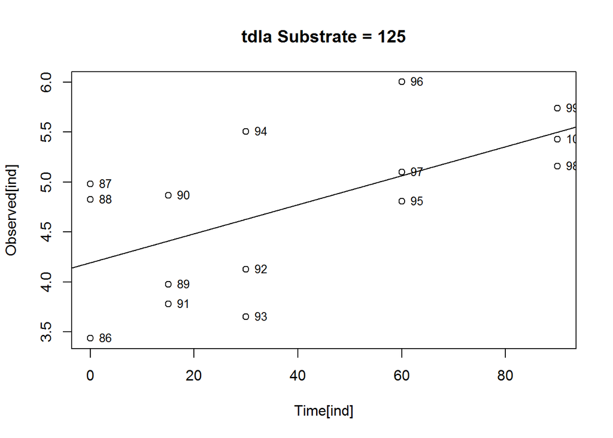

```
## (Intercept)   Time[ind]
##  4.19059517  0.01454007
##             2.5 % 97.5 %
## (Intercept)    NA     NA
## Time[ind]      NA     NA
## [1] "##################################################"
## [1] "##################################################"
## [1] "Substrate =  150"
##  [1] "Indices =  101" "Indices =  102" "Indices =  103" "Indices =  104"
##  [5] "Indices =  105" "Indices =  106" "Indices =  107" "Indices =  108"
##  [9] "Indices =  109" "Indices =  110" "Indices =  111" "Indices =  112"
## [13] "Indices =  113" "Indices =  114" "Indices =  115"
##  [1] "Times = 0"  "Times = 0"  "Times = 0"  "Times = 15" "Times = 15"
##  [6] "Times = 15" "Times = 30" "Times = 30" "Times = 30" "Times = 60"
## [11] "Times = 60" "Times = 60" "Times = 90" "Times = 90" "Times = 90"
##  [1] "Concs = 5.906076855" "Concs = 5.310456154" "Concs = 5.316828489"
##  [4] "Concs = 5.663191766" "Concs = 5.426740549" "Concs = 6.978063453"
##  [7] "Concs = 4.92771323"  "Concs = 5.515269474" "Concs = 7.451213493"
## [10] "Concs = 7.851784896" "Concs = 4.606893218" "Concs = 5.46616595"
## [13] "Concs = 8.552435256" "Concs = 9.168552858" "Concs = 8.094227355"
## Call:
## rlm(formula = Observed[ind] ~ Time[ind])
## Converged in 9 iterations
##
## Coefficients:
## (Intercept)   Time[ind]
##  5.30861592  0.03104684
##
## Degrees of freedom: 15 total; 13 residual
## Scale estimate: 1.01
##
## Call: rlm(formula = Observed[ind] ~ Time[ind])
## Residuals:
##      Min       1Q   Median       3Q      Max
## -2.56453 -0.53616  0.00184  0.63891  1.21119
##
## Coefficients:
##             Value   Std. Error t value
## (Intercept)  5.3086  0.4417    12.0183
## Time[ind]    0.0310  0.0087     3.5598
##
## Residual standard error: 1.009 on 13 degrees of freedom
```

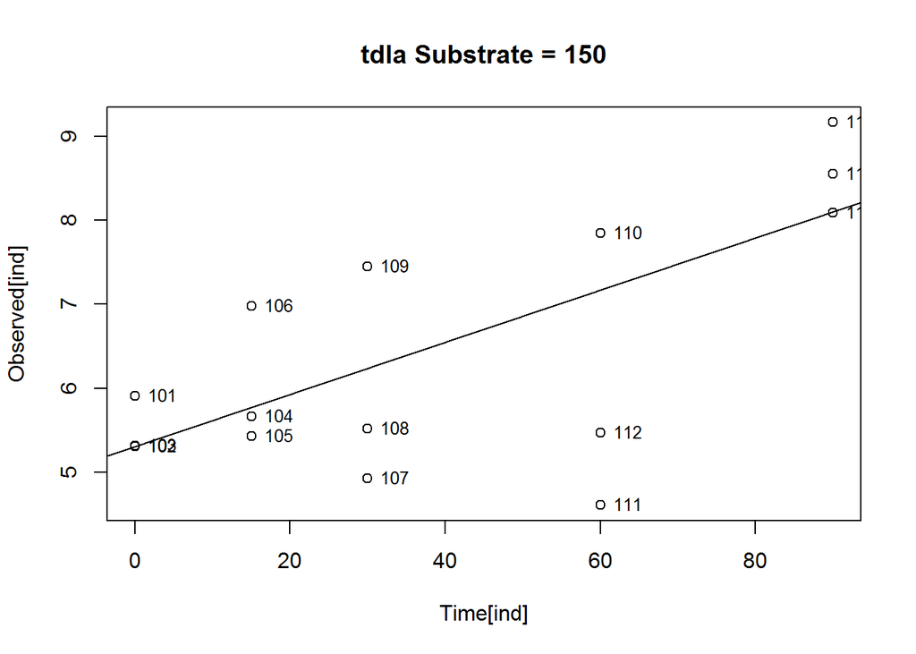

```
## (Intercept)   Time[ind]
##  5.30861592  0.03104684
##             2.5 % 97.5 %
## (Intercept)    NA     NA
## Time[ind]      NA     NA
## [1] "##################################################"
## [1] "##################################################"
## [1] "Substrate =  250"
##  [1] "Indices =  116" "Indices =  117" "Indices =  118" "Indices =  119"
##  [5] "Indices =  120" "Indices =  121" "Indices =  122" "Indices =  123"
##  [9] "Indices =  124" "Indices =  125" "Indices =  126" "Indices =  127"
## [13] "Indices =  128" "Indices =  129" "Indices =  130"
##  [1] "Times = 0"  "Times = 0"  "Times = 0"  "Times = 15" "Times = 15"
##  [6] "Times = 15" "Times = 30" "Times = 30" "Times = 30" "Times = 60"
## [11] "Times = 60" "Times = 60" "Times = 90" "Times = 90" "Times = 90"
##  [1] "Concs = 1.161490438" "Concs = 1.330165483" "Concs = 1.276159877"
##  [4] "Concs = 1.61720898"  "Concs = 1.740756052" "Concs = 1.791062644"
##  [7] "Concs = 2.034457774" "Concs = 2.298567384" "Concs = 2.005605464"
## [10] "Concs = 2.531605274" "Concs = 2.413976625" "Concs = 2.927399787"
## [13] "Concs = 3.522201259" "Concs = 3.463756836" "Concs = 3.15599886"
## Call:
## rlm(formula = Observed[ind] ~ Time[ind])
## Converged in 4 iterations
##
## Coefficients:
## (Intercept)   Time[ind]
##  1.33031671  0.02275505
##
## Degrees of freedom: 15 total; 13 residual
## Scale estimate: 0.177
##
## Call: rlm(formula = Observed[ind] ~ Time[ind])
## Residuals:
##        Min         1Q     Median         3Q        Max
## -0.2816433 -0.1092241 -0.0001512  0.1024527  0.2855991
##
## Coefficients:
##             Value   Std. Error t value
## (Intercept)  1.3303  0.0755    17.6184
## Time[ind]    0.0228  0.0015    15.2628
##
## Residual standard error: 0.1771 on 13 degrees of freedom
```

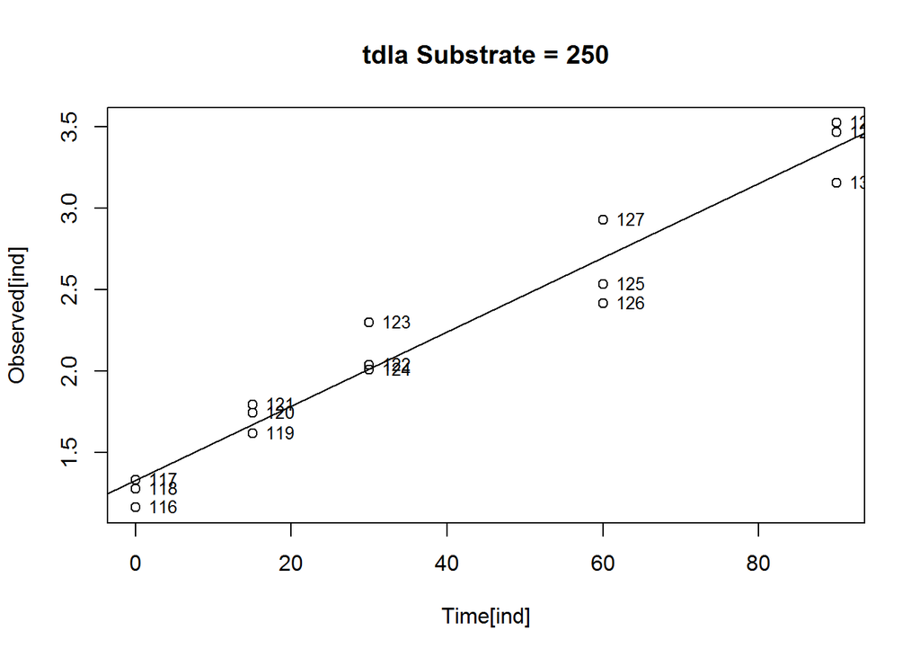

```
## (Intercept)   Time[ind]
##  1.33031671  0.02275505
##             2.5 % 97.5 %
## (Intercept)    NA     NA
## Time[ind]      NA     NA
## [1] "##################################################"
```

```
## 'data.frame':    9 obs. of  2 variables:
##  $ sub: num  0.68 10 2.89 50 75 100 125 150 250
##  $ vel: num  -5.65 46.9 71.67 43.33 67.17 ...
##      sub       vel
## 1   0.68  -5.64955
## 2  10.00  46.90001
## 3   2.89  71.67428
## 4  50.00  43.33150
## 5  75.00  67.16731
## 6 100.00  82.34119
## 7 125.00  72.70033
## 8 150.00 155.23421
## 9 250.00 113.77527
```

```
## [1] "here are the rates"
```

```
##
## Model fitted: Michaelis-Menten (2 parms)
##
## Parameter estimates:
##
##               Estimate Std. Error t-value  p-value
## d:(Intercept)  94.7700    22.1926  4.2703 0.003699 **
## e:(Intercept)   5.2049    10.7357  0.4848 0.642605
## ---
## Signif. codes:  0 '***' 0.001 '**' 0.01 '*' 0.05 '.' 0.1 ' ' 1
##
## Residual standard error:
##
##  36.04578 (7 degrees of freedom)
```

```
## No test available
##
##           ModelDf Log lik Df Chisq value p value
##
## DRC model
```

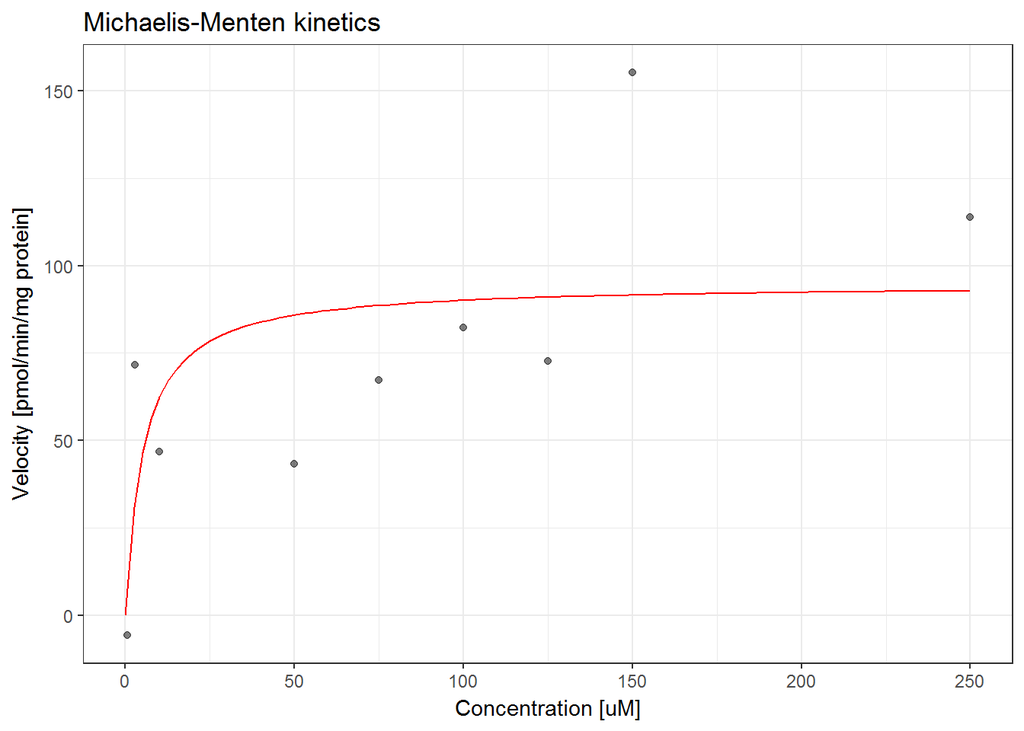

# tdlb

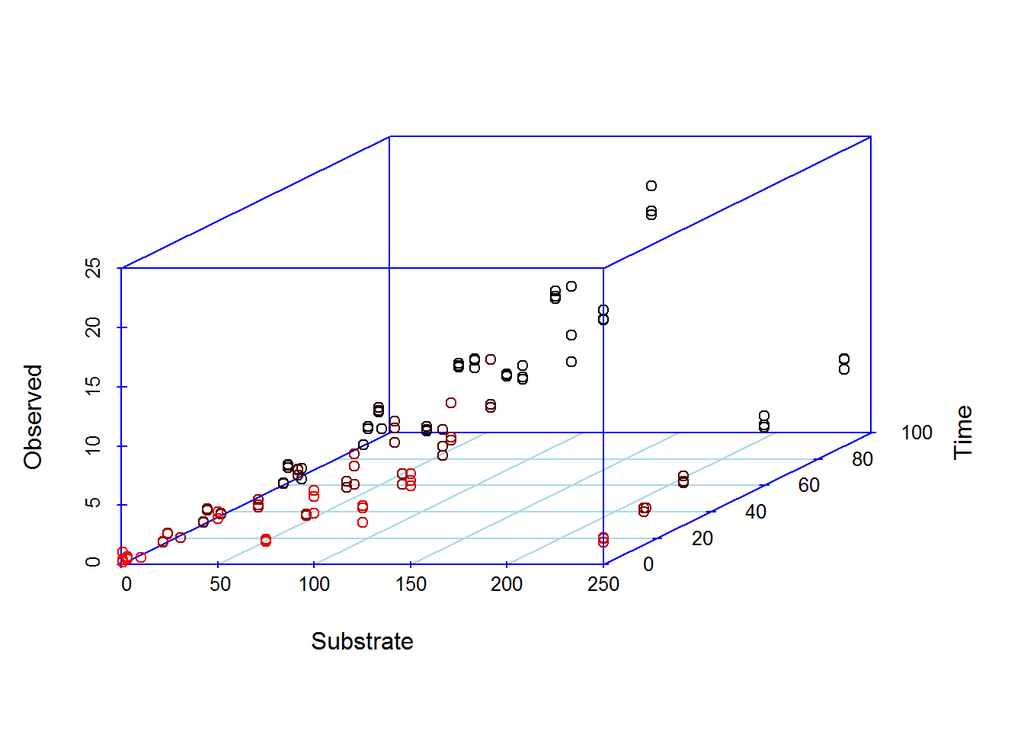

The above figure shows a three-dimensional plot of pesticide substrate concentration, observed concentration and experiment time. We need to condition the pesticide data on the substrate concentrations used in the experiment and regress the observed concentrations over the 90 min period in order to estimate the linear slopes for the Michaelis-Menten kinetic rate constants.

```
## [1] "Substrates:"
```

```
## [1] "##################################################"
## [1] "Substrate =  0.68"
##  [1] "Indices =  1"  "Indices =  2"  "Indices =  3"  "Indices =  4"
##  [5] "Indices =  5"  "Indices =  6"  "Indices =  7"  "Indices =  8"
##  [9] "Indices =  9"  "Indices =  10" "Indices =  11" "Indices =  12"
## [13] "Indices =  13" "Indices =  14" "Indices =  15"
##  [1] "Times = 0"  "Times = 0"  "Times = 0"  "Times = 15" "Times = 15"
##  [6] "Times = 15" "Times = 30" "Times = 30" "Times = 30" "Times = 60"
## [11] "Times = 60" "Times = 60" "Times = 90" "Times = 90" "Times = 90"
##  [1] "Concs = 0.402082422" "Concs = 0.229623234" "Concs = 1.029164926"
##  [4] "Concs = 0.246173803" "Concs = 0.260813596" "Concs = 0.21820036"
##  [7] "Concs = 0.216021451" "Concs = 0.254508505" "Concs = 0.247048129"
## [10] "Concs = 0.153683269" "Concs = 0.218675147" "Concs = 0.173579791"
## [13] "Concs = 0.099158476" "Concs = 0.117730117" "Concs = 0.098721871"
## Call:
## rlm(formula = Observed[ind] ~ Time[ind])
## Converged in 10 iterations
##
## Coefficients:
##  (Intercept)    Time[ind]
##  0.298524176 -0.002117459
##
## Degrees of freedom: 15 total; 13 residual
## Scale estimate: 0.0282
##
## Call: rlm(formula = Observed[ind] ~ Time[ind])
## Residuals:
##       Min        1Q    Median        3Q       Max
## -0.068901 -0.018386 -0.005949  0.015778  0.730641
##
## Coefficients:
##             Value   Std. Error t value
## (Intercept)  0.2985  0.0172    17.3528
## Time[ind]   -0.0021  0.0003    -6.2337
##
## Residual standard error: 0.02815 on 13 degrees of freedom
```

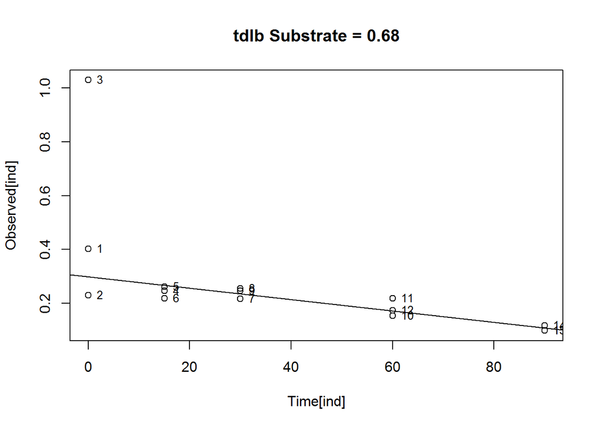

```
##  (Intercept)    Time[ind]
##  0.298524176 -0.002117459
##             2.5 % 97.5 %
## (Intercept)    NA     NA
## Time[ind]      NA     NA
## [1] "##################################################"
## [1] "##################################################"
## [1] "Substrate =  10"
##  [1] "Indices =  16" "Indices =  17" "Indices =  18" "Indices =  19"
##  [5] "Indices =  20" "Indices =  21" "Indices =  22" "Indices =  23"
##  [9] "Indices =  24" "Indices =  25" "Indices =  26" "Indices =  27"
## [13] "Indices =  28" "Indices =  29" "Indices =  30"
##  [1] "Times = 0"  "Times = 0"  "Times = 0"  "Times = 15" "Times = 15"
##  [6] "Times = 15" "Times = 30" "Times = 30" "Times = 30" "Times = 60"
## [11] "Times = 60" "Times = 60" "Times = 90" "Times = 90" "Times = 90"
##  [1] "Concs = 0.591058602" "Concs = 0.59099425"  "Concs = 0.596447836"
##  [4] "Concs = 0.605361148" "Concs = 0.600460446" "Concs = 0.614107575"
##  [7] "Concs = 1.000522185" "Concs = 0.977505725" "Concs = 0.925246462"
## [10] "Concs = 0.532628472" "Concs = 1.430213953" "Concs = 1.469717558"
## [13] "Concs = 1.4730288"   "Concs = 1.430790279" "Concs = 1.474137926"
## Call:
## rlm(formula = Observed[ind] ~ Time[ind])
## Converged in 4 iterations
##
## Coefficients:
## (Intercept)   Time[ind]
##  0.57011461  0.01043547
##
## Degrees of freedom: 15 total; 13 residual
## Scale estimate: 0.14
##
## Call: rlm(formula = Observed[ind] ~ Time[ind])
## Residuals:
##      Min       1Q   Median       3Q      Max
## -0.66361 -0.09553  0.02088  0.06820  0.27347
##
## Coefficients:
##             Value  Std. Error t value
## (Intercept) 0.5701 0.0624     9.1413
## Time[ind]   0.0104 0.0012     8.4742
##
## Residual standard error: 0.1399 on 13 degrees of freedom
```

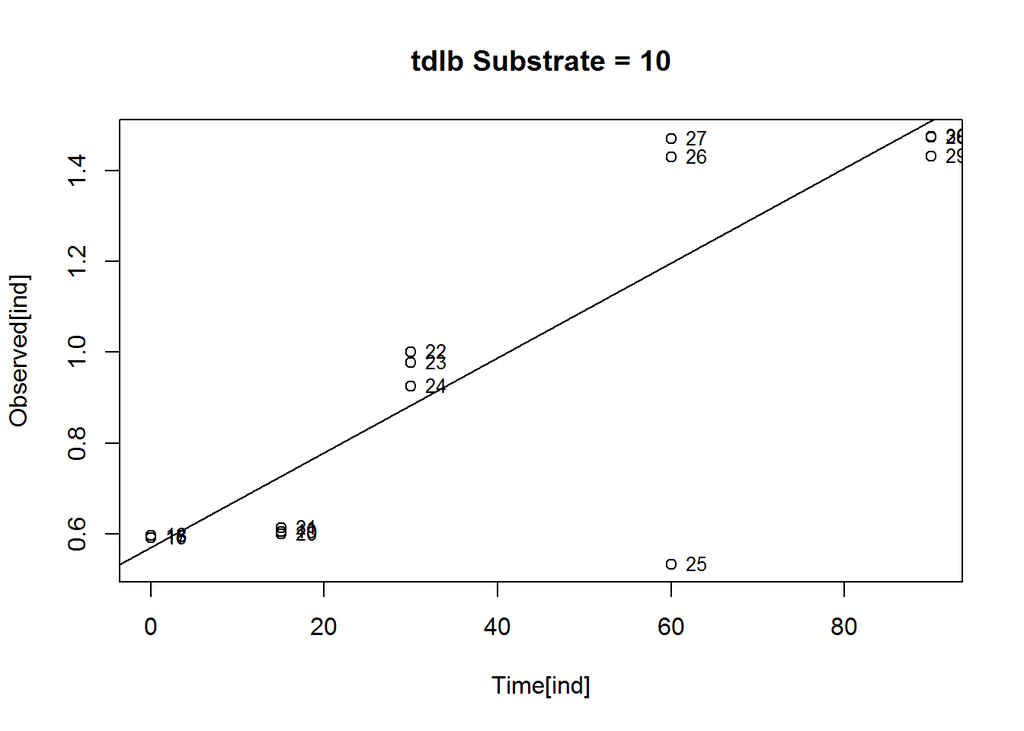

```
## (Intercept)   Time[ind]
##  0.57011461  0.01043547
##             2.5 % 97.5 %
## (Intercept)    NA     NA
## Time[ind]      NA     NA
## [1] "##################################################"
## [1] "##################################################"
## [1] "Substrate =  2.89"
##  [1] "Indices =  31" "Indices =  32" "Indices =  33" "Indices =  34"
##  [5] "Indices =  35" "Indices =  36" "Indices =  37" "Indices =  38"
##  [9] "Indices =  39" "Indices =  40" "Indices =  41" "Indices =  42"
## [13] "Indices =  43" "Indices =  44"
##  [1] "Times = 0"  "Times = 0"  "Times = 0"  "Times = 15" "Times = 15"
##  [6] "Times = 30" "Times = 30" "Times = 30" "Times = 60" "Times = 60"
## [11] "Times = 60" "Times = 90" "Times = 90" "Times = 90"
##  [1] "Concs = 0.444051523" "Concs = 0.522131537" "Concs = 0.647377217"
##  [4] "Concs = 1.006052863" "Concs = 0.896578201" "Concs = 1.244393935"
##  [7] "Concs = 1.329682897" "Concs = 1.395238486" "Concs = 1.720792883"
## [10] "Concs = 1.785675601" "Concs = 1.510536853" "Concs = 1.434768667"
## [13] "Concs = 1.627688816" "Concs = 1.4854364"
## Call:
## rlm(formula = Observed[ind] ~ Time[ind])
## Converged in 1 iterations
##
## Coefficients:
## (Intercept)   Time[ind]
##  0.77467568  0.01088587
##
## Degrees of freedom: 14 total; 12 residual
## Scale estimate: 0.357
##
## Call: rlm(formula = Observed[ind] ~ Time[ind])
## Residuals:
##      Min       1Q   Median       3Q      Max
## -0.33062 -0.22123  0.01335  0.20711  0.35785
##
## Coefficients:
##             Value  Std. Error t value
## (Intercept) 0.7747 0.1077     7.1945
## Time[ind]   0.0109 0.0021     5.2844
##
## Residual standard error: 0.3565 on 12 degrees of freedom
```

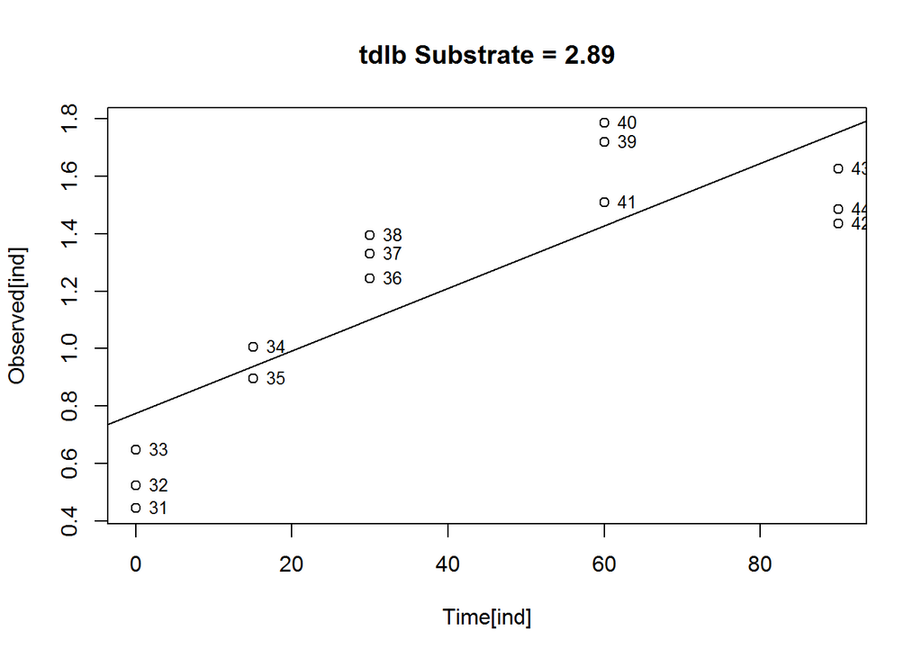

```
## (Intercept)   Time[ind]
##  0.77467568  0.01088587
##             2.5 % 97.5 %
## (Intercept)    NA     NA
## Time[ind]      NA     NA
## [1] "##################################################"
## [1] "##################################################"
## [1] "Substrate =  50"
##  [1] "Indices =  45" "Indices =  46" "Indices =  47" "Indices =  48"
##  [5] "Indices =  49" "Indices =  50" "Indices =  51" "Indices =  52"
##  [9] "Indices =  53" "Indices =  54" "Indices =  55" "Indices =  56"
## [13] "Indices =  57" "Indices =  58" "Indices =  59"
##  [1] "Times = 0"  "Times = 0"  "Times = 0"  "Times = 15" "Times = 15"
##  [6] "Times = 15" "Times = 30" "Times = 30" "Times = 30" "Times = 60"
## [11] "Times = 60" "Times = 60" "Times = 90" "Times = 90" "Times = 90"
##  [1] "Concs = 4.420008817" "Concs = 4.455853897" "Concs = 3.88486422"
##  [4] "Concs = 3.354917958" "Concs = 3.163346168" "Concs = 3.782311427"
##  [7] "Concs = 4.201759321" "Concs = 4.686352643" "Concs = 4.678803809"
## [10] "Concs = 6.224916378" "Concs = 6.611086305" "Concs = 6.317376061"
## [13] "Concs = 6.974457131" "Concs = 6.689927878" "Concs = 6.783763921"
## Call:
## rlm(formula = Observed[ind] ~ Time[ind])
## Converged in 5 iterations
##
## Coefficients:
## (Intercept)   Time[ind]
##  3.66610476  0.03662654
##
## Degrees of freedom: 15 total; 13 residual
## Scale estimate: 0.642
##
## Call: rlm(formula = Observed[ind] ~ Time[ind])
## Residuals:
##      Min       1Q   Median       3Q      Max
## -1.05216 -0.35288 -0.07855  0.40745  0.78975
##
## Coefficients:
##             Value   Std. Error t value
## (Intercept)  3.6661  0.2504    14.6437
## Time[ind]    0.0366  0.0049     7.4094
##
## Residual standard error: 0.6422 on 13 degrees of freedom
```

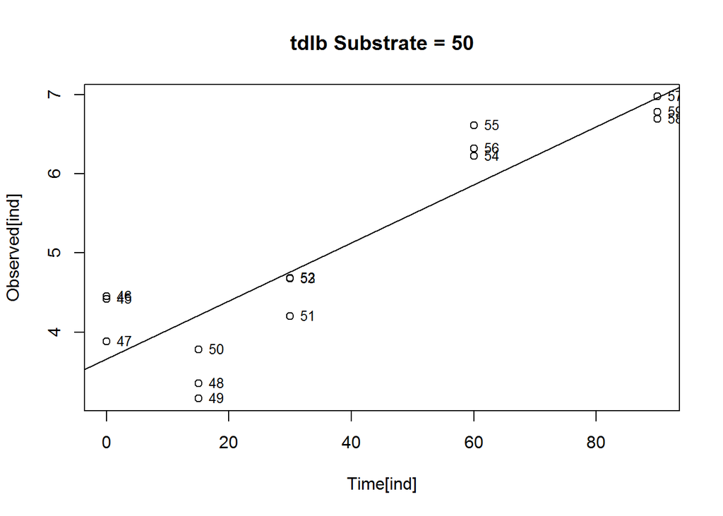

```
## (Intercept)   Time[ind]
##  3.66610476  0.03662654
##             2.5 % 97.5 %
## (Intercept)    NA     NA
## Time[ind]      NA     NA
## [1] "##################################################"
## [1] "##################################################"
## [1] "Substrate =  75"
##  [1] "Indices =  60" "Indices =  61" "Indices =  62" "Indices =  63"
##  [5] "Indices =  64" "Indices =  65" "Indices =  66" "Indices =  67"
##  [9] "Indices =  68" "Indices =  69" "Indices =  70" "Indices =  71"
## [13] "Indices =  72" "Indices =  73" "Indices =  74"
##  [1] "Times = 0"  "Times = 0"  "Times = 0"  "Times = 15" "Times = 15"
##  [6] "Times = 15" "Times = 30" "Times = 30" "Times = 30" "Times = 60"
## [11] "Times = 60" "Times = 60" "Times = 90" "Times = 90" "Times = 90"
##  [1] "Concs = 2.139127395" "Concs = 1.925635709" "Concs = 1.972983193"
##  [4] "Concs = 2.619651895" "Concs = 2.444620075" "Concs = 2.590170122"
##  [7] "Concs = 3.656825463" "Concs = 3.151748549" "Concs = 3.165542915"
## [10] "Concs = 5.005868893" "Concs = 4.625552648" "Concs = 4.703858162"
## [13] "Concs = 6.05746387"  "Concs = 5.962852161" "Concs = 5.870416575"
## Call:
## rlm(formula = Observed[ind] ~ Time[ind])
## Converged in 7 iterations
##
## Coefficients:
## (Intercept)   Time[ind]
##  1.94399274  0.04489882
##
## Degrees of freedom: 15 total; 13 residual
## Scale estimate: 0.108
##
## Call: rlm(formula = Observed[ind] ~ Time[ind])
## Residuals:
##      Min       1Q   Median       3Q      Max
## -0.17285 -0.07089 -0.01237  0.06926  0.36795
##
## Coefficients:
##             Value   Std. Error t value
## (Intercept)  1.9440  0.0611    31.7958
## Time[ind]    0.0449  0.0012    37.1923
##
## Residual standard error: 0.1076 on 13 degrees of freedom
```

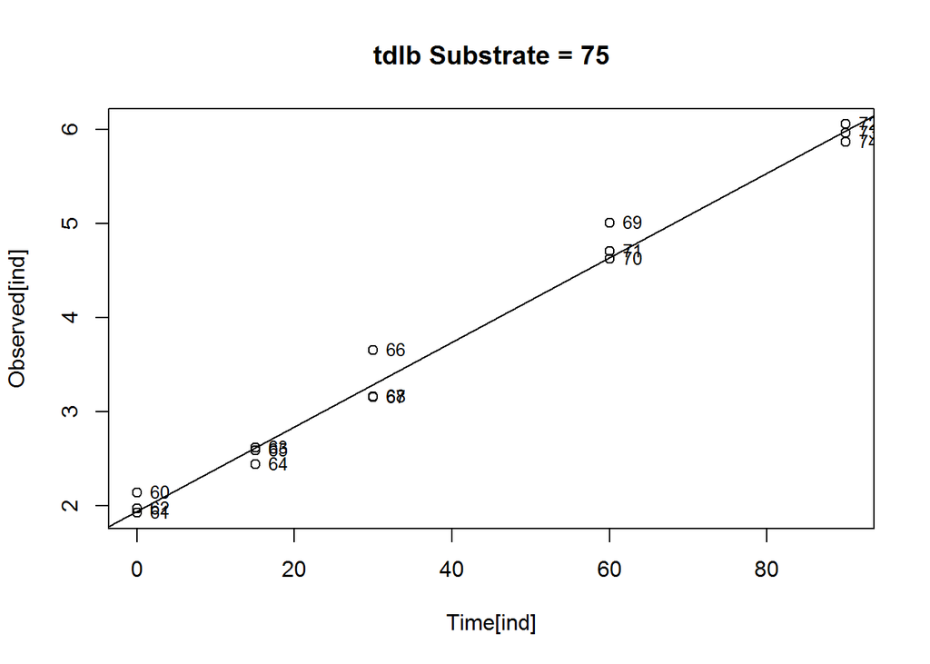

```
## (Intercept)   Time[ind]
##  1.94399274  0.04489882
##             2.5 % 97.5 %
## (Intercept)    NA     NA
## Time[ind]      NA     NA
## [1] "##################################################"
## [1] "##################################################"
## [1] "Substrate =  100"
##  [1] "Indices =  75" "Indices =  76" "Indices =  77" "Indices =  78"
##  [5] "Indices =  79" "Indices =  80" "Indices =  81" "Indices =  82"
##  [9] "Indices =  83" "Indices =  84" "Indices =  85" "Indices =  86"
## [13] "Indices =  87" "Indices =  88" "Indices =  89"
##  [1] "Times = 0"  "Times = 0"  "Times = 0"  "Times = 15" "Times = 15"
##  [6] "Times = 15" "Times = 30" "Times = 30" "Times = 30" "Times = 60"
## [11] "Times = 60" "Times = 60" "Times = 90" "Times = 90" "Times = 90"
##  [1] "Concs = 4.340154496" "Concs = 5.746715294" "Concs = 6.239756024"
##  [4] "Concs = 5.07924542"  "Concs = 6.622466721" "Concs = 7.675132104"
##  [7] "Concs = 6.988408726" "Concs = 8.790287998" "Concs = 8.213244554"
## [10] "Concs = 9.919792078" "Concs = 10.56863759" "Concs = 10.70603998"
## [13] "Concs = 12.46725643" "Concs = 13.07253625" "Concs = 12.65724209"
## Call:
## rlm(formula = Observed[ind] ~ Time[ind])
## Converged in 10 iterations
##
## Coefficients:
## (Intercept)   Time[ind]
##  5.65402796  0.07885133
##
## Degrees of freedom: 15 total; 13 residual
## Scale estimate: 0.477
##
## Call: rlm(formula = Observed[ind] ~ Time[ind])
## Residuals:
##      Min       1Q   Median       3Q      Max
## -1.75755 -0.37435  0.09269  0.32141  0.83833
##
## Coefficients:
##             Value   Std. Error t value
## (Intercept)  5.6540  0.3146    17.9732
## Time[ind]    0.0789  0.0062    12.6946
##
## Residual standard error: 0.4772 on 13 degrees of freedom
```

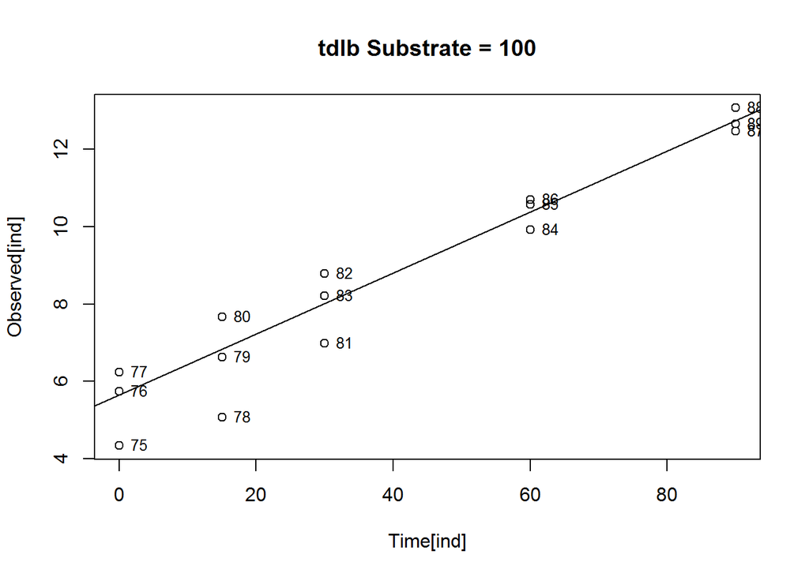

```
## (Intercept)   Time[ind]
##  5.65402796  0.07885133
##             2.5 % 97.5 %
## (Intercept)    NA     NA
## Time[ind]      NA     NA
## [1] "##################################################"
## [1] "##################################################"
## [1] "Substrate =  125"
##  [1] "Indices =  90"  "Indices =  91"  "Indices =  92"  "Indices =  93"
##  [5] "Indices =  94"  "Indices =  95"  "Indices =  96"  "Indices =  97"
##  [9] "Indices =  98"  "Indices =  99"  "Indices =  100" "Indices =  101"
## [13] "Indices =  102" "Indices =  103" "Indices =  104"
##  [1] "Times = 0"  "Times = 0"  "Times = 0"  "Times = 15" "Times = 15"
##  [6] "Times = 15" "Times = 30" "Times = 30" "Times = 30" "Times = 60"
## [11] "Times = 60" "Times = 60" "Times = 90" "Times = 90" "Times = 90"
##  [1] "Concs = 3.521226196" "Concs = 4.943307935" "Concs = 4.765753969"
##  [4] "Concs = 5.063397684" "Concs = 5.998752957" "Concs = 5.064421433"
##  [7] "Concs = 6.628504248" "Concs = 5.845275026" "Concs = 8.057762608"
## [10] "Concs = 8.979581881" "Concs = 10.11723473" "Concs = 9.1649147"
## [13] "Concs = 10.65628882" "Concs = 11.49107644" "Concs = 10.73563287"
## Call:
## rlm(formula = Observed[ind] ~ Time[ind])
## Converged in 7 iterations
##
## Coefficients:
## (Intercept)   Time[ind]
##  4.41750674  0.07548815
##
## Degrees of freedom: 15 total; 13 residual
## Scale estimate: 0.72
##
## Call: rlm(formula = Observed[ind] ~ Time[ind])
## Residuals:
##      Min       1Q   Median       3Q      Max
## -0.89628 -0.48592  0.03279  0.39859  1.37561
##
## Coefficients:
##             Value   Std. Error t value
## (Intercept)  4.4175  0.2993    14.7587
## Time[ind]    0.0755  0.0059    12.7730
##
## Residual standard error: 0.7197 on 13 degrees of freedom
```

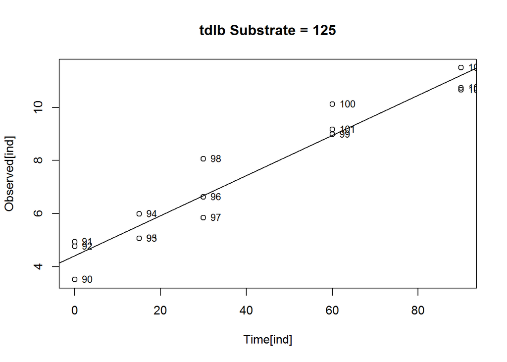

```
## (Intercept)   Time[ind]
##  4.41750674  0.07548815
##             2.5 % 97.5 %
## (Intercept)    NA     NA
## Time[ind]      NA     NA
## [1] "##################################################"
## [1] "##################################################"
## [1] "Substrate =  150"
##  [1] "Indices =  105" "Indices =  106" "Indices =  107" "Indices =  108"
##  [5] "Indices =  109" "Indices =  110" "Indices =  111" "Indices =  112"
##  [9] "Indices =  113" "Indices =  114" "Indices =  115" "Indices =  116"
## [13] "Indices =  117" "Indices =  118" "Indices =  119"
##  [1] "Times = 0"  "Times = 0"  "Times = 0"  "Times = 15" "Times = 15"
##  [6] "Times = 15" "Times = 30" "Times = 30" "Times = 30" "Times = 60"
## [11] "Times = 60" "Times = 60" "Times = 90" "Times = 90" "Times = 90"
##  [1] "Concs = 7.640849396" "Concs = 7.10603124"  "Concs = 6.640858802"
##  [4] "Concs = 9.089124895" "Concs = 8.803908189" "Concs = 11.98416488"
##  [7] "Concs = 9.939688614" "Concs = 10.20547106" "Concs = 13.94661101"
## [10] "Concs = 16.79956857" "Concs = 10.45604655" "Concs = 12.66707679"
## [13] "Concs = 19.81332574" "Concs = 21.96311112" "Concs = 19.53811526"
## Call:
## rlm(formula = Observed[ind] ~ Time[ind])
## Converged in 7 iterations
##
## Coefficients:
## (Intercept)   Time[ind]
##   7.1604842   0.1399395
##
## Degrees of freedom: 15 total; 13 residual
## Scale estimate: 1.71
##
## Call: rlm(formula = Observed[ind] ~ Time[ind])
## Residuals:
##     Min      1Q  Median      3Q     Max
## -5.1008 -0.8364 -0.1705  0.8615  2.7246
##
## Coefficients:
##             Value  Std. Error t value
## (Intercept) 7.1605 0.9066     7.8981
## Time[ind]   0.1399 0.0179     7.8174
##
## Residual standard error: 1.71 on 13 degrees of freedom
```

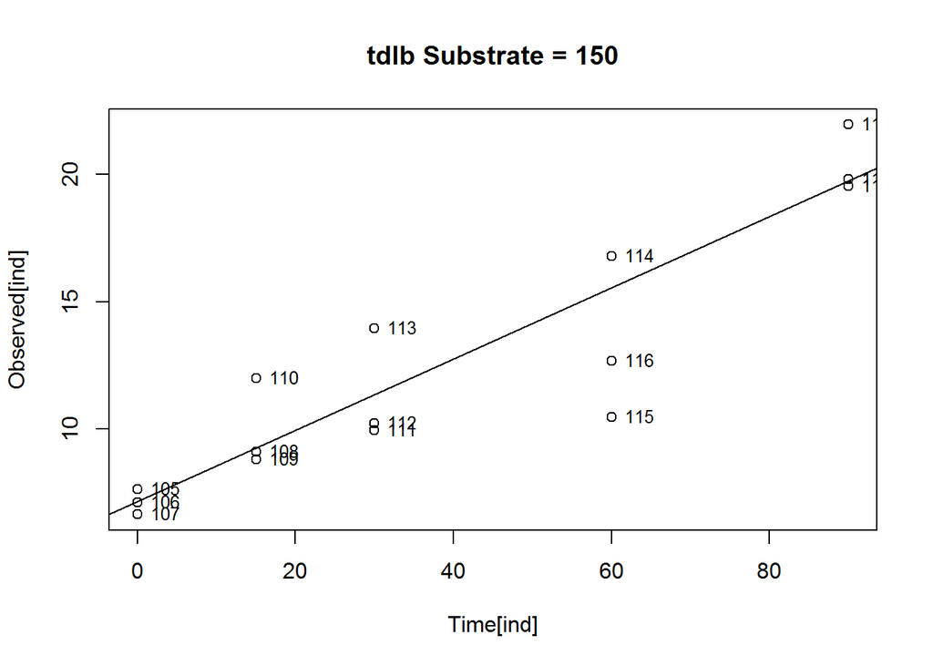

```
## (Intercept)   Time[ind]
##   7.1604842   0.1399395
##             2.5 % 97.5 %
## (Intercept)    NA     NA
## Time[ind]      NA     NA
## [1] "##################################################"
## [1] "##################################################"
## [1] "Substrate =  250"
##  [1] "Indices =  120" "Indices =  121" "Indices =  122" "Indices =  123"
##  [5] "Indices =  124" "Indices =  125" "Indices =  126" "Indices =  127"
##  [9] "Indices =  128" "Indices =  129" "Indices =  130" "Indices =  131"
## [13] "Indices =  132" "Indices =  133" "Indices =  134"
##  [1] "Times = 0"  "Times = 0"  "Times = 0"  "Times = 15" "Times = 16"
##  [6] "Times = 15" "Times = 30" "Times = 30" "Times = 30" "Times = 60"
## [11] "Times = 60" "Times = 60" "Times = 90" "Times = 90" "Times = 90"
##  [1] "Concs = 1.882425922" "Concs = 2.195061335" "Concs = 2.256987196"
##  [4] "Concs = 2.75479897"  "Concs = 3.000097525" "Concs = 3.101102812"
##  [7] "Concs = 3.558031493" "Concs = 4.11837035"  "Concs = 3.670459998"
## [10] "Concs = 5.129625668" "Concs = 4.946854195" "Concs = 5.887165323"
## [13] "Concs = 7.340919995" "Concs = 7.2807978"   "Concs = 6.475160389"
## Call:
## rlm(formula = Observed[ind] ~ Time[ind])
## Converged in 6 iterations
##
## Coefficients:
## (Intercept)   Time[ind]
##   2.1112848   0.0545614
##
## Degrees of freedom: 15 total; 13 residual
## Scale estimate: 0.339
##
## Call: rlm(formula = Observed[ind] ~ Time[ind])
## Residuals:
##      Min       1Q   Median       3Q      Max
## -0.54665 -0.20948  0.01583  0.21519  0.50220
##
## Coefficients:
##             Value   Std. Error t value
## (Intercept)  2.1113  0.1430    14.7644
## Time[ind]    0.0546  0.0028    19.3319
##
## Residual standard error: 0.3393 on 13 degrees of freedom
```

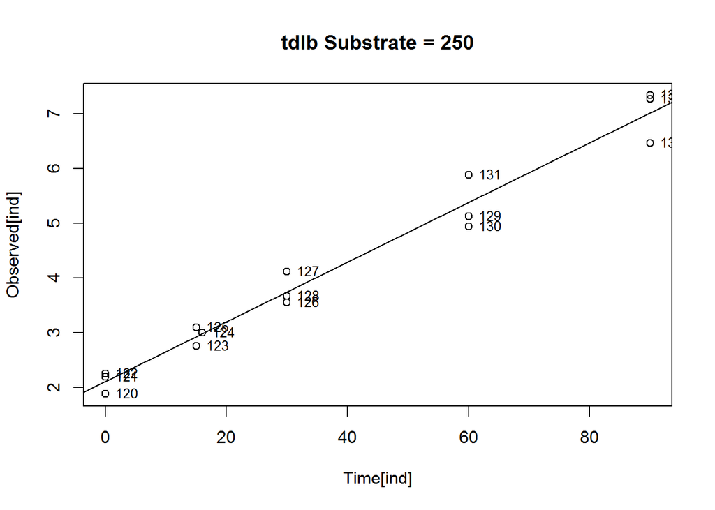

```
## (Intercept)   Time[ind]
##   2.1112848   0.0545614
##             2.5 % 97.5 %
## (Intercept)    NA     NA
## Time[ind]      NA     NA
## [1] "##################################################"
```

```
## 'data.frame':    9 obs. of  2 variables:
##  $ sub: num  0.68 10 2.89 50 75 100 125 150 250
##  $ vel: num  -10.6 52.2 54.4 183.1 224.5 ...
##      sub       vel
## 1   0.68 -10.58730
## 2  10.00  52.17737
## 3   2.89  54.42935
## 4  50.00 183.13272
## 5  75.00 224.49410
## 6 100.00 394.25665
## 7 125.00 377.44074
## 8 150.00 699.69766
## 9 250.00 272.80699
```

```
## [1] "here are the rates"
```

```
##
## Model fitted: Michaelis-Menten (2 parms)
##
## Parameter estimates:
##
##               Estimate Std. Error t-value p-value
## d:(Intercept)  580.844    233.349  2.4892 0.04165 *
## e:(Intercept)   65.065     70.236  0.9264 0.38508
## ---
## Signif. codes:  0 '***' 0.001 '**' 0.01 '*' 0.05 '.' 0.1 ' ' 1
##
## Residual standard error:
##
##  140.4322 (7 degrees of freedom)
```

```
## No test available
##
##           ModelDf Log lik Df Chisq value p value
##
## DRC model
```

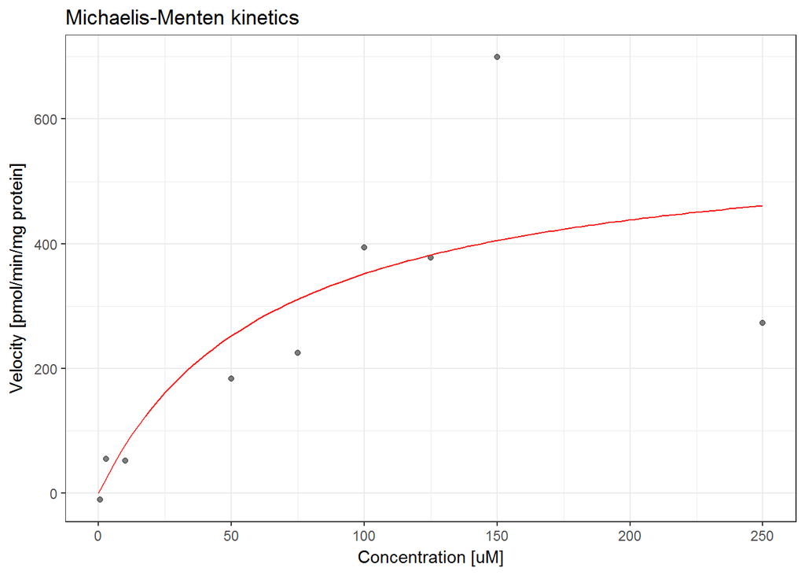

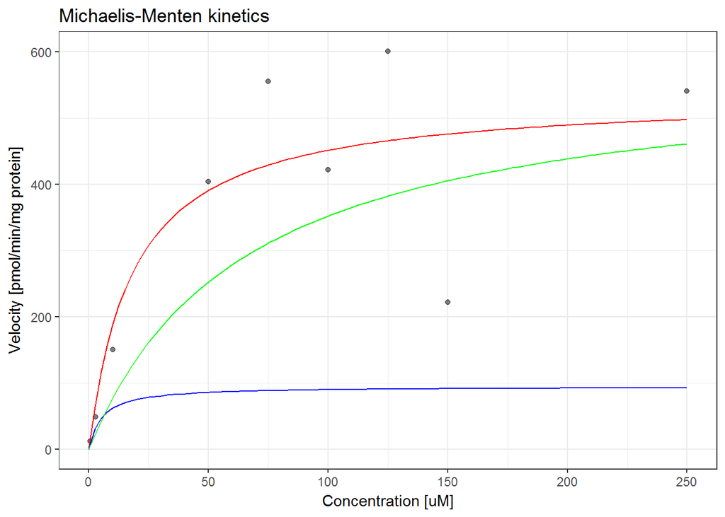

# fipronil

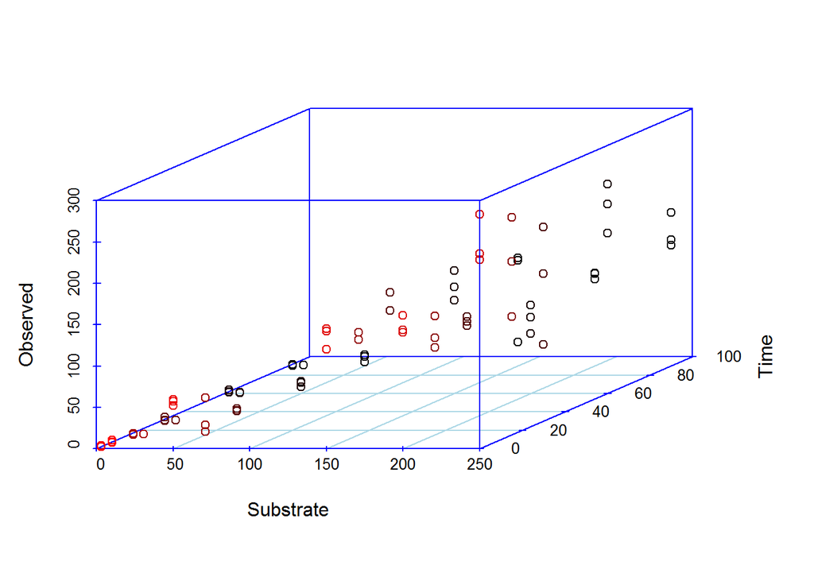

The above figure shows a three-dimensional plot of pesticide substrate concentration, observed concentration and experiment time. We need to condition the pesticide data on the substrate concentrations used in the experiment and regress the observed concentrations over the 90 min period in order to estimate the linear slopes for the Michaelis-Menten kinetic rate constants.

```
## [1] "Substrates:"
```

```
## [1] "##################################################"
## [1] "Substrate =  10"
##  [1] "Indices =  1"  "Indices =  2"  "Indices =  3"  "Indices =  4"
##  [5] "Indices =  5"  "Indices =  6"  "Indices =  7"  "Indices =  8"
##  [9] "Indices =  9"  "Indices =  10" "Indices =  11" "Indices =  12"
## [13] "Indices =  13" "Indices =  14"
##  [1] "Times = 0"  "Times = 0"  "Times = 0"  "Times = 15" "Times = 15"
##  [6] "Times = 30" "Times = 30" "Times = 30" "Times = 60" "Times = 60"
## [11] "Times = 60" "Times = 90" "Times = 90" "Times = 90"
##  [1] "Concs = 10.57355056" "Concs = 7.131297707" "Concs = 7.981665852"
##  [4] "Concs = 0.760199385" "Concs = 1.187171779" "Concs = 0.834748222"
##  [7] "Concs = 1.254233702" "Concs = 0.921331337" "Concs = 1.038856477"
## [10] "Concs = 1.236949156" "Concs = 0.821536565" "Concs = 1.117931895"
## [13] "Concs = 1.271923746" "Concs = 0.999477721"
## Call:
## rlm(formula = Observed[ind] ~ Time[ind])
## Converged in 7 iterations
##
## Coefficients:
## (Intercept)   Time[ind]
##  4.77392000 -0.05518259
##
## Degrees of freedom: 14 total; 12 residual
## Scale estimate: 3.01
##
## Call: rlm(formula = Observed[ind] ~ Time[ind])
## Residuals:
##     Min      1Q  Median      3Q     Max
## -3.1860 -2.1139 -0.3251  1.4259  5.7996
##
## Coefficients:
##             Value   Std. Error t value
## (Intercept)  4.7739  1.1172     4.2731
## Time[ind]   -0.0552  0.0214    -2.5818
##
## Residual standard error: 3.011 on 12 degrees of freedom
```

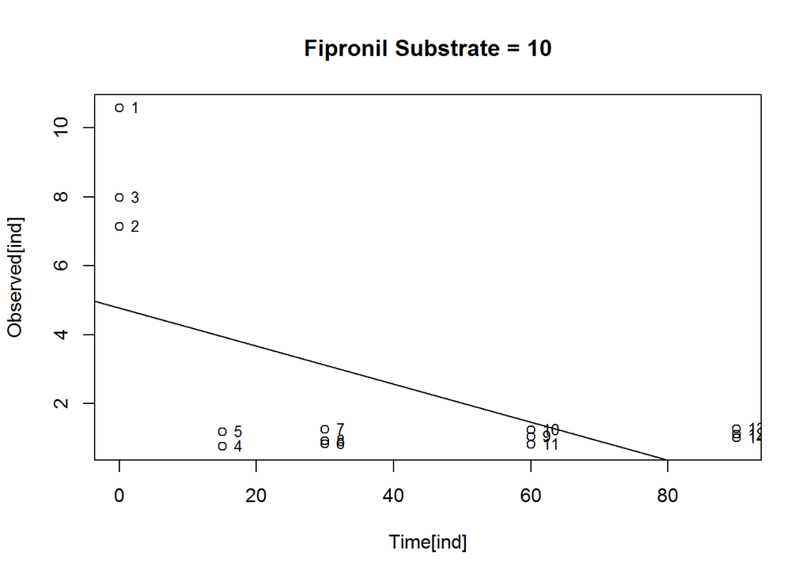

```
## (Intercept)   Time[ind]
##  4.77392000 -0.05518259
##             2.5 % 97.5 %
## (Intercept)    NA     NA
## Time[ind]      NA     NA
## [1] "##################################################"
## [1] "##################################################"
## [1] "Substrate =  2.89"
##  [1] "Indices =  15" "Indices =  16" "Indices =  17" "Indices =  18"
##  [5] "Indices =  19" "Indices =  20" "Indices =  21" "Indices =  22"
##  [9] "Indices =  23" "Indices =  24" "Indices =  25" "Indices =  26"
## [13] "Indices =  27" "Indices =  28" "Indices =  29"
##  [1] "Times = 0"  "Times = 0"  "Times = 0"  "Times = 15" "Times = 15"
##  [6] "Times = 15" "Times = 30" "Times = 30" "Times = 30" "Times = 60"
## [11] "Times = 60" "Times = 60" "Times = 90" "Times = 90" "Times = 90"
##  [1] "Concs = 3.553166435" "Concs = 2.185797914" "Concs = 4.160901096"
##  [4] "Concs = 0.961731316" "Concs = 0.608701865" "Concs = 2.021395291"
##  [7] "Concs = 0.34095865"  "Concs = 1.416552854" "Concs = 4.678731136"
## [10] "Concs = 1.597568113" "Concs = 2.059112975" "Concs = 4.336224939"
## [13] "Concs = 0.73593197"  "Concs = 1.01143428"  "Concs = 2.098949857"
## Call:
## rlm(formula = Observed[ind] ~ Time[ind])
## Converged in 8 iterations
##
## Coefficients:
## (Intercept)   Time[ind]
##  2.40740669 -0.01119571
##
## Degrees of freedom: 15 total; 13 residual
## Scale estimate: 1.04
##
## Call: rlm(formula = Observed[ind] ~ Time[ind])
## Residuals:
##     Min      1Q  Median      3Q     Max
## -1.7306 -0.6594 -0.2181  0.9225  2.6072
##
## Coefficients:
##             Value   Std. Error t value
## (Intercept)  2.4074  0.6844     3.5175
## Time[ind]   -0.0112  0.0135    -0.8285
##
## Residual standard error: 1.037 on 13 degrees of freedom
```

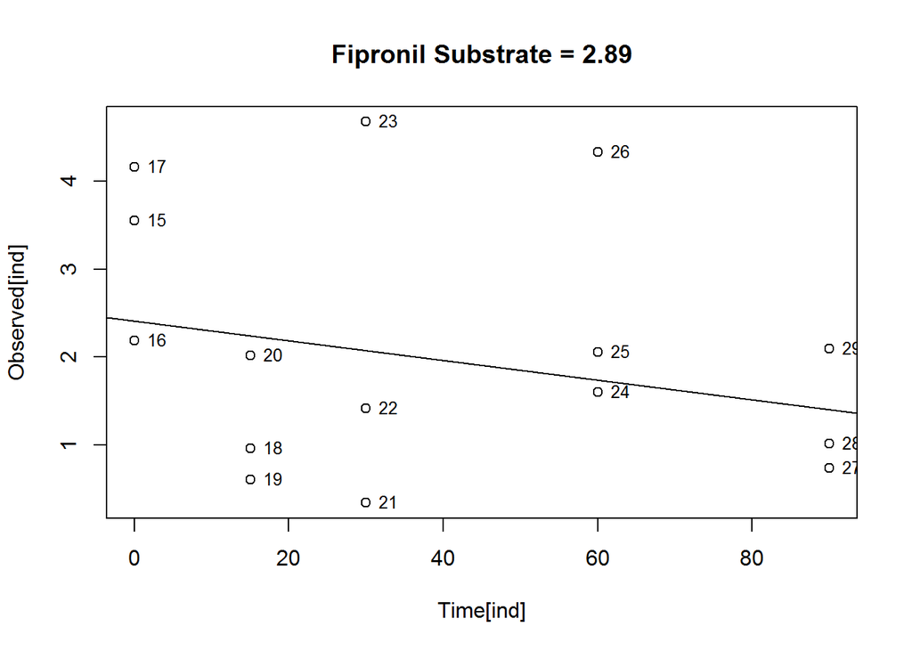

```
## (Intercept)   Time[ind]
##  2.40740669 -0.01119571
##             2.5 % 97.5 %
## (Intercept)    NA     NA
## Time[ind]      NA     NA
## [1] "##################################################"
## [1] "##################################################"
## [1] "Substrate =  50"
##  [1] "Indices =  30" "Indices =  31" "Indices =  32" "Indices =  33"
##  [5] "Indices =  34" "Indices =  35" "Indices =  36" "Indices =  37"
##  [9] "Indices =  38" "Indices =  39" "Indices =  40" "Indices =  41"
## [13] "Indices =  42" "Indices =  43" "Indices =  44"
##  [1] "Times = 0"  "Times = 0"  "Times = 0"  "Times = 15" "Times = 15"
##  [6] "Times = 15" "Times = 30" "Times = 30" "Times = 30" "Times = 60"
## [11] "Times = 60" "Times = 60" "Times = 90" "Times = 90" "Times = 90"
##  [1] "Concs = 57.00766972" "Concs = 59.13744418" "Concs = 52.24750551"
##  [4] "Concs = 44.67698383" "Concs = 3.819060247" "Concs = 12.37000976"
##  [7] "Concs = 15.34578007" "Concs = 13.08895186" "Concs = 11.97726763"
## [10] "Concs = 14.81813289" "Concs = 13.10848562" "Concs = 7.910416718"
## [13] "Concs = 13.23099713" "Concs = 4.710351591" "Concs = 11.65193188"
## Call:
## rlm(formula = Observed[ind] ~ Time[ind])
## Converged in 5 iterations
##
## Coefficients:
## (Intercept)   Time[ind]
##  37.9917238  -0.3961134
##
## Degrees of freedom: 15 total; 13 residual
## Scale estimate: 18.7
##
## Call: rlm(formula = Observed[ind] ~ Time[ind])
## Residuals:
##      Min       1Q   Median       3Q      Max
## -28.2310 -11.8910   0.5932  11.7582  21.1457
##
## Coefficients:
##             Value   Std. Error t value
## (Intercept) 37.9917  6.5765     5.7769
## Time[ind]   -0.3961  0.1299    -3.0505
##
## Residual standard error: 18.72 on 13 degrees of freedom
```

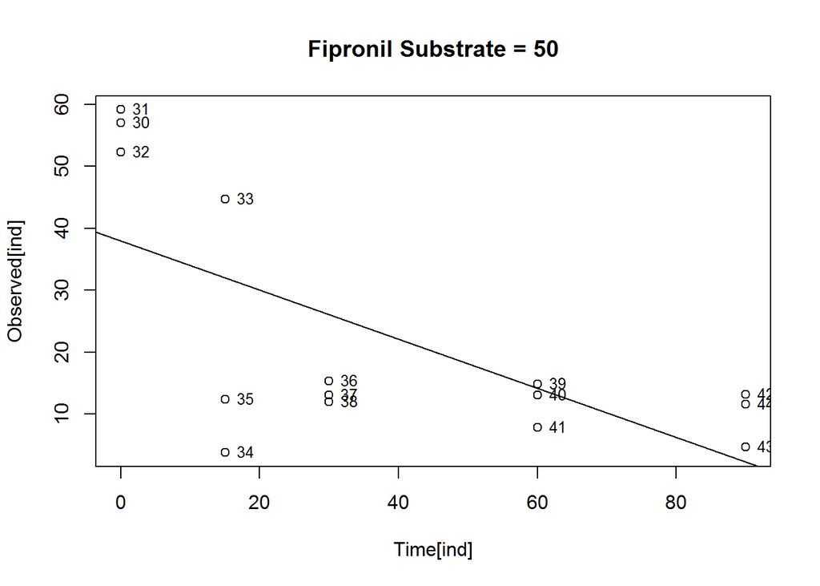

```
## (Intercept)   Time[ind]
##  37.9917238  -0.3961134
##             2.5 % 97.5 %
## (Intercept)    NA     NA
## Time[ind]      NA     NA
## [1] "##################################################"
## [1] "##################################################"
## [1] "Substrate =  150"
##  [1] "Indices =  45" "Indices =  46" "Indices =  47" "Indices =  48"
##  [5] "Indices =  49" "Indices =  50" "Indices =  51" "Indices =  52"
##  [9] "Indices =  53" "Indices =  54" "Indices =  55" "Indices =  56"
## [13] "Indices =  57" "Indices =  58"
##  [1] "Times = 0"  "Times = 0"  "Times = 0"  "Times = 15" "Times = 15"
##  [6] "Times = 30" "Times = 30" "Times = 30" "Times = 60" "Times = 60"
## [11] "Times = 60" "Times = 90" "Times = 90" "Times = 90"
##  [1] "Concs = 120.1840369" "Concs = 145.3520797" "Concs = 142.3332536"
##  [4] "Concs = 115.428861"  "Concs = 124.2452738" "Concs = 133.9244833"
##  [7] "Concs = 155.8614698" "Concs = 133.3381427" "Concs = 112.8005214"
## [10] "Concs = 148.8202467" "Concs = 129.1596217" "Concs = 128.0330109"
## [13] "Concs = 130.3403839" "Concs = 29.18643658"
## Call:
## rlm(formula = Observed[ind] ~ Time[ind])
## Converged in 6 iterations
##
## Coefficients:
## (Intercept)   Time[ind]
## 134.7988101  -0.1242694
##
## Degrees of freedom: 14 total; 12 residual
## Scale estimate: 14.3
##
## Call: rlm(formula = Observed[ind] ~ Time[ind])
## Residuals:
##     Min      1Q  Median      3Q     Max
## -94.428 -13.079   2.561   7.332  24.791
##
## Coefficients:
##             Value    Std. Error t value
## (Intercept) 134.7988   7.5838    17.7747
## Time[ind]    -0.1243   0.1451    -0.8565
##
## Residual standard error: 14.26 on 12 degrees of freedom
```

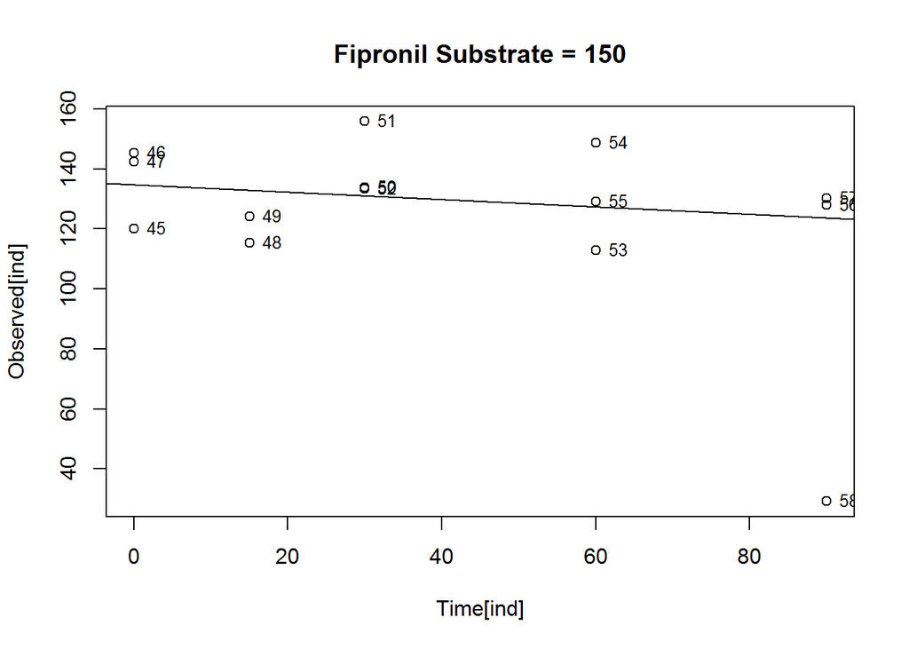

```
## (Intercept)   Time[ind]
## 134.7988101  -0.1242694
##             2.5 % 97.5 %
## (Intercept)    NA     NA
## Time[ind]      NA     NA
## [1] "##################################################"
## [1] "##################################################"
## [1] "Substrate =  200"
##  [1] "Indices =  59" "Indices =  60" "Indices =  61" "Indices =  62"
##  [5] "Indices =  63" "Indices =  64" "Indices =  65" "Indices =  66"
##  [9] "Indices =  67" "Indices =  68" "Indices =  69" "Indices =  70"
## [13] "Indices =  71" "Indices =  72" "Indices =  73"
##  [1] "Times = 0"  "Times = 0"  "Times = 0"  "Times = 15" "Times = 15"
##  [6] "Times = 15" "Times = 30" "Times = 30" "Times = 30" "Times = 60"
## [11] "Times = 60" "Times = 60" "Times = 90" "Times = 90" "Times = 90"
##  [1] "Concs = 161.3373216" "Concs = 140.3753919" "Concs = 143.641415"
##  [4] "Concs = 143.5820327" "Concs = 117.0381728" "Concs = 105.3992543"
##  [7] "Concs = 120.601107"  "Concs = 115.1379412" "Concs = 126.1830373"
## [10] "Concs = 91.91948648" "Concs = 106.6462813" "Concs = 72.50149496"
## [13] "Concs = 112.4063583" "Concs = 105.3992543" "Concs = 111.7531537"
## Call:
## rlm(formula = Observed[ind] ~ Time[ind])
## Converged in 5 iterations
##
## Coefficients:
## (Intercept)   Time[ind]
## 135.3425626  -0.4178514
##
## Degrees of freedom: 15 total; 13 residual
## Scale estimate: 17.8
##
## Call: rlm(formula = Observed[ind] ~ Time[ind])
## Residuals:
##     Min      1Q  Median      3Q     Max
## -37.770  -9.853   3.376  11.158  25.995
##
## Coefficients:
##             Value    Std. Error t value
## (Intercept) 135.3426   7.3189    18.4923
## Time[ind]    -0.4179   0.1445    -2.8915
##
## Residual standard error: 17.84 on 13 degrees of freedom
```

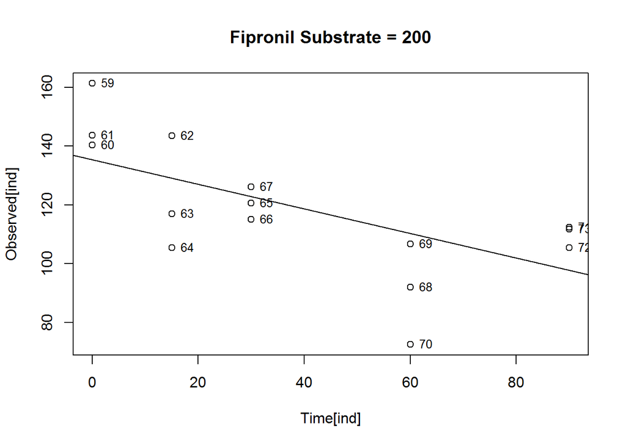

```
## (Intercept)   Time[ind]
## 135.3425626  -0.4178514
##             2.5 % 97.5 %
## (Intercept)    NA     NA
## Time[ind]      NA     NA
## [1] "##################################################"
## [1] "##################################################"
## [1] "Substrate =  250"
##  [1] "Indices =  74" "Indices =  75" "Indices =  76" "Indices =  77"
##  [5] "Indices =  78" "Indices =  79" "Indices =  80" "Indices =  81"
##  [9] "Indices =  82" "Indices =  83" "Indices =  84" "Indices =  85"
## [13] "Indices =  86" "Indices =  87" "Indices =  88"
##  [1] "Times = 0"  "Times = 0"  "Times = 0"  "Times = 15" "Times = 15"
##  [6] "Times = 15" "Times = 30" "Times = 30" "Times = 30" "Times = 60"
## [11] "Times = 60" "Times = 60" "Times = 90" "Times = 90" "Times = 90"
##  [1] "Concs = 235.9498416" "Concs = 283.6965927" "Concs = 228.2284198"
##  [4] "Concs = 263.2111879" "Concs = 209.7915555" "Concs = 143.1352"
##  [7] "Concs = 178.2755482" "Concs = 234.8467813" "Concs = 92.39442817"
## [10] "Concs = 193.7183918" "Concs = 253.2836456" "Concs = 228.8587399"
## [13] "Concs = 145.9716406" "Concs = 185.3666498" "Concs = 152.9051623"
## Call:
## rlm(formula = Observed[ind] ~ Time[ind])
## Converged in 6 iterations
##
## Coefficients:
## (Intercept)   Time[ind]
## 235.9725402  -0.7131667
##
## Degrees of freedom: 15 total; 13 residual
## Scale estimate: 38.3
##
## Call: rlm(formula = Observed[ind] ~ Time[ind])
## Residuals:
##       Min        1Q    Median        3Q       Max
## -122.1831  -22.3491   -0.0227   27.9727   60.1011
##
## Coefficients:
##             Value    Std. Error t value
## (Intercept) 235.9725  18.4816    12.7680
## Time[ind]    -0.7132   0.3649    -1.9543
##
## Residual standard error: 38.27 on 13 degrees of freedom
```

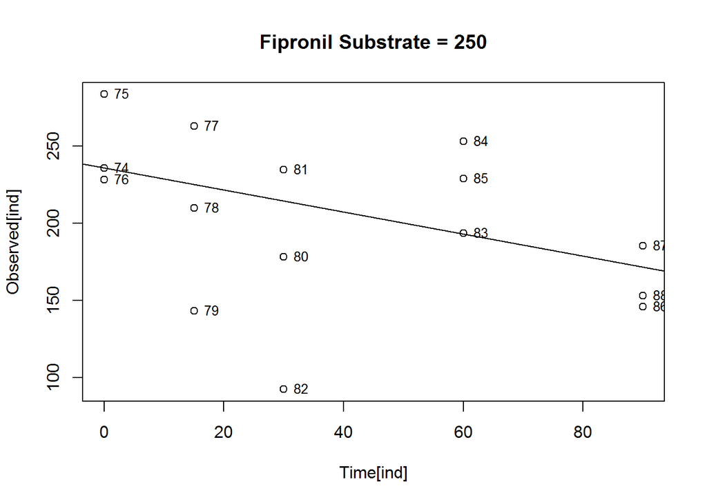

```
## (Intercept)   Time[ind]
## 235.9725402  -0.7131667
##             2.5 % 97.5 %
## (Intercept)    NA     NA
## Time[ind]      NA     NA
## [1] "##################################################"
```

```
## 'data.frame':    6 obs. of  2 variables:
##  $ sub: num  10 2.89 50 150 200 250
##  $ vel: num  276 56 1981 621 2089 ...
##      sub        vel
## 1  10.00  275.91293
## 2   2.89   55.97857
## 3  50.00 1980.56687
## 4 150.00  621.34678
## 5 200.00 2089.25688
## 6 250.00 3565.83353
```

```
## [1] "here are the rates"
```

```
##
## Model fitted: Michaelis-Menten (2 parms)
##
## Parameter estimates:
##
##               Estimate Std. Error t-value p-value
## d:(Intercept)  27430.7   113663.3  0.2413  0.8212
## e:(Intercept)   2121.6     9640.7  0.2201  0.8366
##
## Residual standard error:
##
##  973.0673 (4 degrees of freedom)
```

```
## No test available
##
##           ModelDf Log lik Df Chisq value p value
##
## DRC model
```

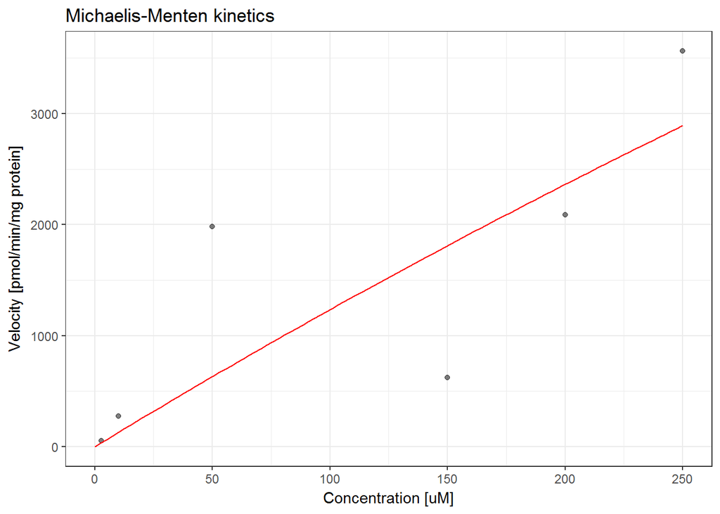

# fipsulf

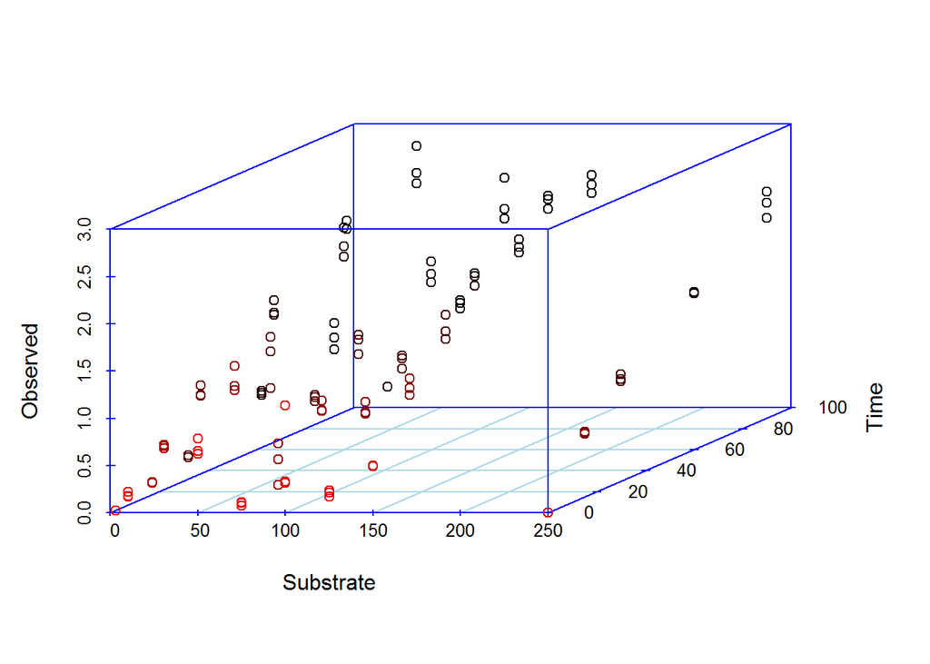

The above figure shows a three-dimensional plot of pesticide substrate concentration, observed concentration and experiment time. We need to condition the pesticide data on the substrate concentrations used in the experiment and regress the observed concentrations over the 90 min period in order to estimate the linear slopes for the Michaelis-Menten kinetic rate constants.

```
## [1] "Substrates:"
```

```
## [1] "##################################################"
## [1] "Substrate =  10"
##  [1] "Indices =  1"  "Indices =  2"  "Indices =  3"  "Indices =  4"
##  [5] "Indices =  5"  "Indices =  6"  "Indices =  7"  "Indices =  8"
##  [9] "Indices =  9"  "Indices =  10" "Indices =  11" "Indices =  12"
## [13] "Indices =  13" "Indices =  14" "Indices =  15"
##  [1] "Times = 0"  "Times = 0"  "Times = 0"  "Times = 15" "Times = 15"
##  [6] "Times = 15" "Times = 30" "Times = 30" "Times = 30" "Times = 60"
## [11] "Times = 60" "Times = 60" "Times = 90" "Times = 90" "Times = 90"
##  [1] "Concs = 0.218453069" "Concs = 0.16722553"  "Concs = 0.177409431"
##  [4] "Concs = 0.51830331"  "Concs = 0.552214025" "Concs = 0.537364947"
##  [7] "Concs = 0.913205394" "Concs = 1.016825543" "Concs = 0.901827084"
## [10] "Concs = 1.42587892"  "Concs = 1.446211798" "Concs = 1.577890064"
## [13] "Concs = 1.999928264" "Concs = 2.086184093" "Concs = 2.088468137"
## Call:
## rlm(formula = Observed[ind] ~ Time[ind])
## Converged in 7 iterations
##
## Coefficients:
## (Intercept)   Time[ind]
##  0.23088822  0.02060305
##
## Degrees of freedom: 15 total; 13 residual
## Scale estimate: 0.0611
##
## Call: rlm(formula = Observed[ind] ~ Time[ind])
## Residuals:
##       Min        1Q    Median        3Q       Max
## -0.085234 -0.031411 -0.002569  0.032564  0.167846
##
## Coefficients:
##             Value   Std. Error t value
## (Intercept)  0.2309  0.0280     8.2602
## Time[ind]    0.0206  0.0006    37.3306
##
## Residual standard error: 0.06107 on 13 degrees of freedom
```

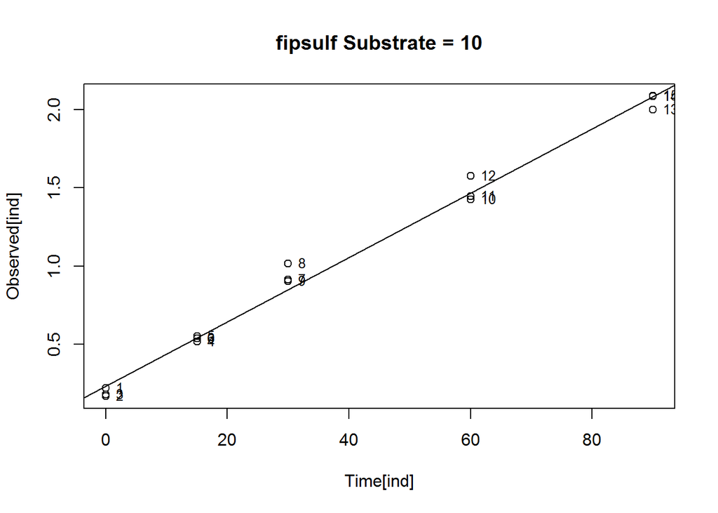

```
## (Intercept)   Time[ind]
##  0.23088822  0.02060305
##             2.5 % 97.5 %
## (Intercept)    NA     NA
## Time[ind]      NA     NA
## [1] "##################################################"
## [1] "##################################################"
## [1] "Substrate =  2.89"
##  [1] "Indices =  16" "Indices =  17" "Indices =  18" "Indices =  19"
##  [5] "Indices =  20" "Indices =  21" "Indices =  22" "Indices =  23"
##  [9] "Indices =  24" "Indices =  25" "Indices =  26" "Indices =  27"
## [13] "Indices =  28" "Indices =  29" "Indices =  30"
##  [1] "Times = 0"  "Times = 0"  "Times = 0"  "Times = 15" "Times = 15"
##  [6] "Times = 15" "Times = 30" "Times = 30" "Times = 30" "Times = 60"
## [11] "Times = 60" "Times = 60" "Times = 90" "Times = 90" "Times = 90"
##  [1] "Concs = 0.024236972" "Concs = 0.022488202" "Concs = 0.025605583"
##  [4] "Concs = 0.153953365" "Concs = 0.14676346"  "Concs = 0.150213178"
##  [7] "Concs = 0.255979534" "Concs = 0.273005759" "Concs = 0.277157181"
## [10] "Concs = 0.600301918" "Concs = 0.578169686" "Concs = 0.619389899"
## [13] "Concs = 0.72919882"  "Concs = 0.855702746" "Concs = 1.005390251"
## Call:
## rlm(formula = Observed[ind] ~ Time[ind])
## Converged in 7 iterations
##
## Coefficients:
## (Intercept)   Time[ind]
## 0.011529754 0.009462775
##
## Degrees of freedom: 15 total; 13 residual
## Scale estimate: 0.0209
##
## Call: rlm(formula = Observed[ind] ~ Time[ind])
## Residuals:
##       Min        1Q    Median        3Q       Max
## -0.133981 -0.012866 -0.001127  0.013392  0.142211
##
## Coefficients:
##             Value   Std. Error t value
## (Intercept)  0.0115  0.0114     1.0106
## Time[ind]    0.0095  0.0002    42.0051
##
## Residual standard error: 0.02087 on 13 degrees of freedom
```

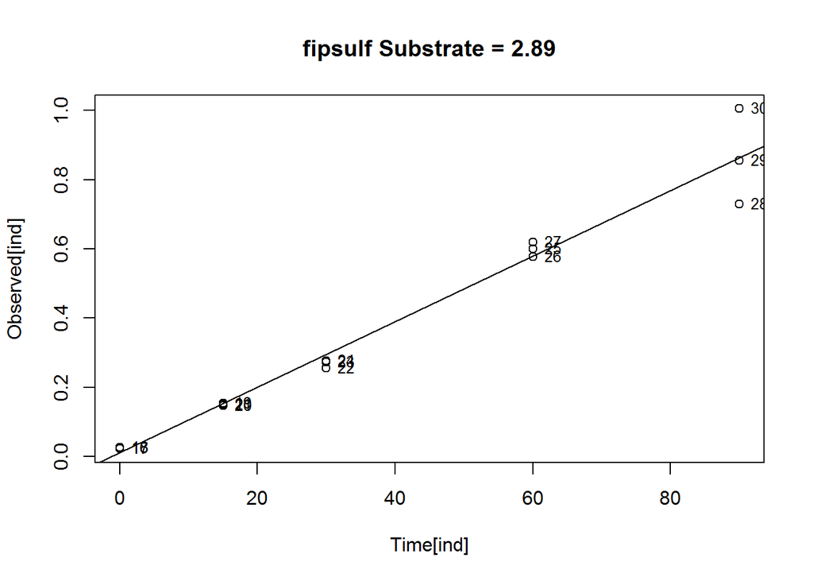

```
## (Intercept)   Time[ind]
## 0.011529754 0.009462775
##             2.5 % 97.5 %
## (Intercept)    NA     NA
## Time[ind]      NA     NA
## [1] "##################################################"
## [1] "##################################################"
## [1] "Substrate =  50"
##  [1] "Indices =  31" "Indices =  32" "Indices =  33" "Indices =  34"
##  [5] "Indices =  35" "Indices =  36" "Indices =  37" "Indices =  38"
##  [9] "Indices =  39" "Indices =  40" "Indices =  41" "Indices =  42"
## [13] "Indices =  43" "Indices =  44" "Indices =  45"
##  [1] "Times = 0"  "Times = 0"  "Times = 0"  "Times = 15" "Times = 15"
##  [6] "Times = 15" "Times = 30" "Times = 30" "Times = 30" "Times = 60"
## [11] "Times = 60" "Times = 60" "Times = 90" "Times = 90" "Times = 90"
##  [1] "Concs = 0.785110353" "Concs = 0.651662128" "Concs = 0.623272931"
##  [4] "Concs = 1.389739341" "Concs = 1.129679656" "Concs = 1.171944943"
##  [7] "Concs = 0.985037522" "Concs = 1.525224345" "Concs = 1.371585733"
## [10] "Concs = 2.350595335" "Concs = 2.151757802" "Concs = 2.044295988"
## [13] "Concs = 2.879243198" "Concs = 2.483251478" "Concs = 2.593598032"
## Call:
## rlm(formula = Observed[ind] ~ Time[ind])
## Converged in 6 iterations
##
## Coefficients:
## (Intercept)   Time[ind]
##  0.77463889  0.02158359
##
## Degrees of freedom: 15 total; 13 residual
## Scale estimate: 0.182
##
## Call: rlm(formula = Observed[ind] ~ Time[ind])
## Residuals:
##      Min       1Q   Median       3Q      Max
## -0.43711 -0.12327  0.01047  0.09259  0.29135
##
## Coefficients:
##             Value   Std. Error t value
## (Intercept)  0.7746  0.0849     9.1189
## Time[ind]    0.0216  0.0017    12.8679
##
## Residual standard error: 0.1823 on 13 degrees of freedom
```

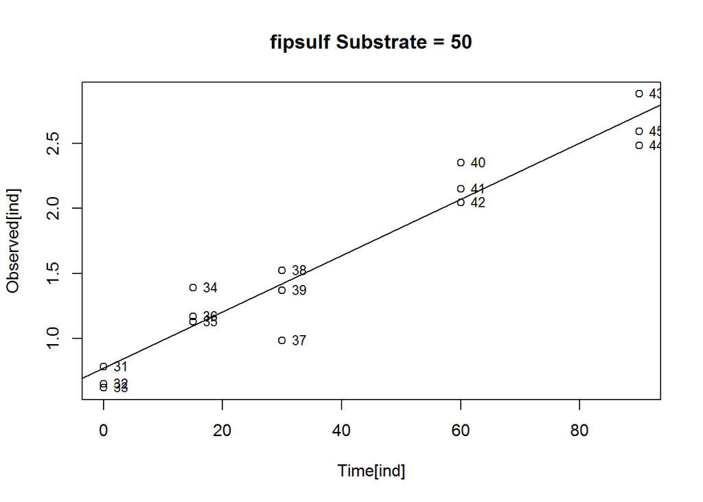

```
## (Intercept)   Time[ind]
##  0.77463889  0.02158359
##             2.5 % 97.5 %
## (Intercept)    NA     NA
## Time[ind]      NA     NA
## [1] "##################################################"
## [1] "##################################################"
## [1] "Substrate =  75"
##  [1] "Indices =  46" "Indices =  47" "Indices =  48" "Indices =  49"
##  [5] "Indices =  50" "Indices =  51" "Indices =  52" "Indices =  53"
##  [9] "Indices =  54" "Indices =  55" "Indices =  56" "Indices =  57"
## [13] "Indices =  58"
##  [1] "Times = 0"  "Times = 0"  "Times = 0"  "Times = 15" "Times = 15"
##  [6] "Times = 15" "Times = 30" "Times = 30" "Times = 30" "Times = 60"
## [11] "Times = 90" "Times = 90" "Times = 90"
##  [1] "Concs = 0.076232122" "Concs = 0.11093207"  "Concs = 0.100698461"
##  [4] "Concs = 0.563272498" "Concs = 0.126440587" "Concs = 0.39526057"
##  [7] "Concs = 0.846041523" "Concs = 0.893588458" "Concs = 0.911664361"
## [10] "Concs = 0.669794737" "Concs = 1.21631006"  "Concs = 1.162617749"
## [13] "Concs = 1.251568939"
## Call:
## rlm(formula = Observed[ind] ~ Time[ind])
## Converged in 5 iterations
##
## Coefficients:
## (Intercept)   Time[ind]
##  0.23494866  0.01127804
##
## Degrees of freedom: 13 total; 11 residual
## Scale estimate: 0.235
##
## Call: rlm(formula = Observed[ind] ~ Time[ind])
## Residuals:
##      Min       1Q   Median       3Q      Max
## -0.27768 -0.13425 -0.03366  0.15915  0.33837
##
## Coefficients:
##             Value  Std. Error t value
## (Intercept) 0.2349 0.1055     2.2260
## Time[ind]   0.0113 0.0022     5.2411
##
## Residual standard error: 0.2353 on 11 degrees of freedom
```

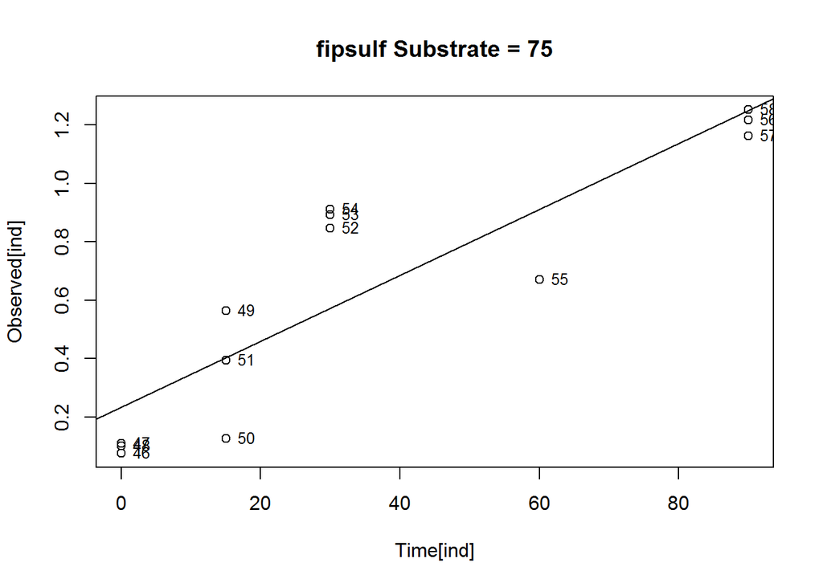

```
## (Intercept)   Time[ind]
##  0.23494866  0.01127804
##             2.5 % 97.5 %
## (Intercept)    NA     NA
## Time[ind]      NA     NA
## [1] "##################################################"
## [1] "##################################################"
## [1] "Substrate =  100"
##  [1] "Indices =  59" "Indices =  60" "Indices =  61" "Indices =  62"
##  [5] "Indices =  63" "Indices =  64" "Indices =  65" "Indices =  66"
##  [9] "Indices =  67" "Indices =  68" "Indices =  69" "Indices =  70"
## [13] "Indices =  71" "Indices =  72" "Indices =  73"
##  [1] "Times = 0"  "Times = 0"  "Times = 0"  "Times = 15" "Times = 15"
##  [6] "Times = 15" "Times = 30" "Times = 30" "Times = 30" "Times = 60"
## [11] "Times = 60" "Times = 60" "Times = 90" "Times = 90" "Times = 90"
##  [1] "Concs = 1.13821052"  "Concs = 0.334004631" "Concs = 0.316680231"
##  [4] "Concs = 0.918283437" "Concs = 0.90859124"  "Concs = 1.020530824"
##  [7] "Concs = 1.343619416" "Concs = 1.498547233" "Concs = 1.547942907"
## [10] "Concs = 1.768354064" "Concs = 1.991371294" "Concs = 1.8610216"
## [13] "Concs = 2.114823643" "Concs = 2.540092398" "Concs = 2.212077131"
## Call:
## rlm(formula = Observed[ind] ~ Time[ind])
## Converged in 7 iterations
##
## Coefficients:
## (Intercept)   Time[ind]
##  0.71345477  0.01851378
##
## Degrees of freedom: 15 total; 13 residual
## Scale estimate: 0.248
##
## Call: rlm(formula = Observed[ind] ~ Time[ind])
## Residuals:
##      Min       1Q   Median       3Q      Max
## -0.39677 -0.12509  0.02937  0.16374  0.42476
##
## Coefficients:
##             Value  Std. Error t value
## (Intercept) 0.7135 0.1161     6.1434
## Time[ind]   0.0185 0.0023     8.0739
##
## Residual standard error: 0.2477 on 13 degrees of freedom
```

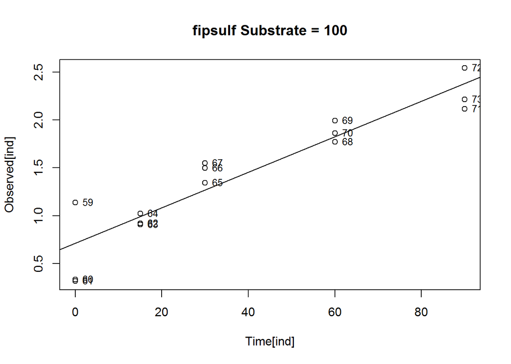

```
## (Intercept)   Time[ind]
##  0.71345477  0.01851378
##             2.5 % 97.5 %
## (Intercept)    NA     NA
## Time[ind]      NA     NA
## [1] "##################################################"
## [1] "##################################################"
## [1] "Substrate =  125"
##  [1] "Indices =  74" "Indices =  75" "Indices =  76" "Indices =  77"
##  [5] "Indices =  78" "Indices =  79" "Indices =  80" "Indices =  81"
##  [9] "Indices =  82" "Indices =  83" "Indices =  84" "Indices =  85"
## [13] "Indices =  86" "Indices =  87" "Indices =  88"
##  [1] "Times = 0"  "Times = 0"  "Times = 0"  "Times = 15" "Times = 15"
##  [6] "Times = 15" "Times = 30" "Times = 30" "Times = 30" "Times = 60"
## [11] "Times = 60" "Times = 60" "Times = 90" "Times = 90" "Times = 90"
##  [1] "Concs = 0.238292686" "Concs = 0.169686663" "Concs = 0.214656616"
##  [4] "Concs = 0.896250609" "Concs = 1.003144725" "Concs = 0.878415124"
##  [7] "Concs = 1.296498301" "Concs = 1.188470589" "Concs = 1.332743895"
## [10] "Concs = 1.838994297" "Concs = 1.735055265" "Concs = 1.867403256"
## [13] "Concs = 2.350429219" "Concs = 2.217648418" "Concs = 2.313686352"
## Call:
## rlm(formula = Observed[ind] ~ Time[ind])
## Converged in 12 iterations
##
## Coefficients:
## (Intercept)   Time[ind]
##   0.4930084   0.0211471
##
## Degrees of freedom: 15 total; 13 residual
## Scale estimate: 0.157
##
## Call: rlm(formula = Observed[ind] ~ Time[ind])
## Residuals:
##      Min       1Q   Median       3Q      Max
## -0.32332 -0.13058  0.06105  0.09580  0.20532
##
## Coefficients:
##             Value   Std. Error t value
## (Intercept)  0.4930  0.0816     6.0416
## Time[ind]    0.0211  0.0016    13.1247
##
## Residual standard error: 0.1565 on 13 degrees of freedom
```

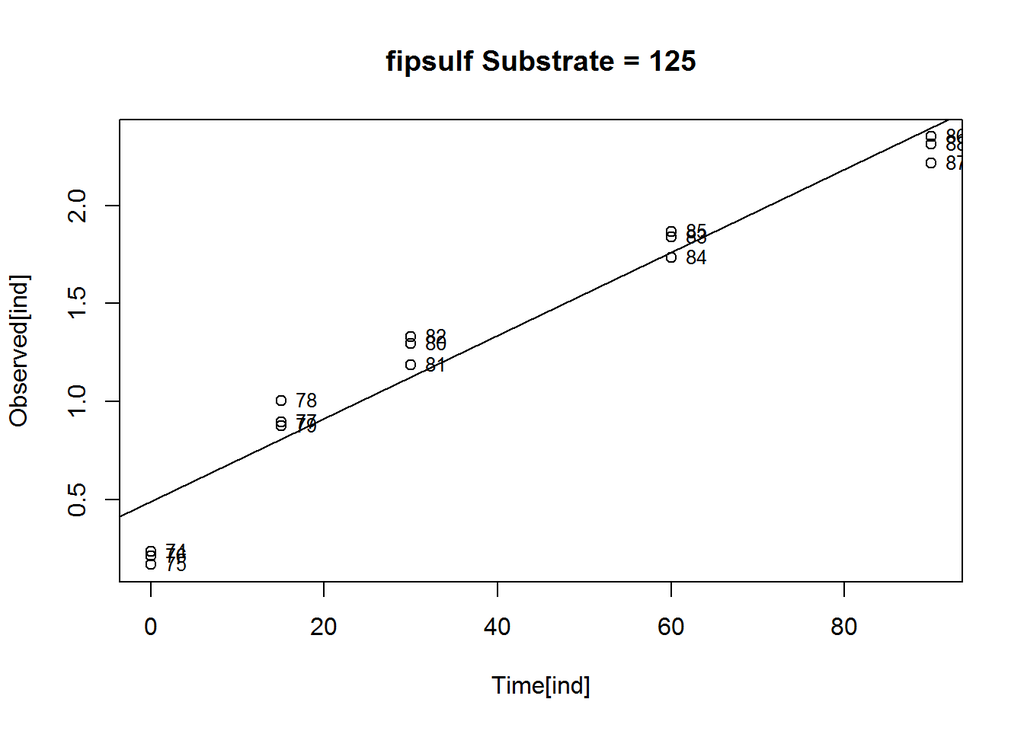

```
## (Intercept)   Time[ind]
##   0.4930084   0.0211471
##             2.5 % 97.5 %
## (Intercept)    NA     NA
## Time[ind]      NA     NA
## [1] "##################################################"
## [1] "##################################################"
## [1] "Substrate =  150"
##  [1] "Indices =  89"  "Indices =  90"  "Indices =  91"  "Indices =  92"
##  [5] "Indices =  93"  "Indices =  94"  "Indices =  95"  "Indices =  96"
##  [9] "Indices =  97"  "Indices =  98"  "Indices =  99"  "Indices =  100"
## [13] "Indices =  101" "Indices =  102" "Indices =  103"
##  [1] "Times = 0"  "Times = 0"  "Times = 0"  "Times = 15" "Times = 15"
##  [6] "Times = 15" "Times = 30" "Times = 30" "Times = 30" "Times = 60"
## [11] "Times = 60" "Times = 60" "Times = 90" "Times = 90" "Times = 90"
##  [1] "Concs = 0.490201412" "Concs = 0.500310765" "Concs = 0.501022601"
##  [4] "Concs = 1.255933807" "Concs = 1.075230731" "Concs = 1.154821858"
##  [7] "Concs = 1.506153651" "Concs = 1.58449239"  "Concs = 1.763878617"
## [10] "Concs = 2.22530088"  "Concs = 2.148002728" "Concs = 2.084269049"
## [13] "Concs = 2.471763558" "Concs = 2.574367323" "Concs = 2.385468469"
## Call:
## rlm(formula = Observed[ind] ~ Time[ind])
## Converged in 3 iterations
##
## Coefficients:
## (Intercept)   Time[ind]
##  0.76080280  0.02102169
##
## Degrees of freedom: 15 total; 13 residual
## Scale estimate: 0.268
##
## Call: rlm(formula = Observed[ind] ~ Time[ind])
## Residuals:
##      Min       1Q   Median       3Q      Max
## -0.27060 -0.22039  0.06216  0.15285  0.37243
##
## Coefficients:
##             Value   Std. Error t value
## (Intercept)  0.7608  0.0940     8.0903
## Time[ind]    0.0210  0.0019    11.3215
##
## Residual standard error: 0.2683 on 13 degrees of freedom
```

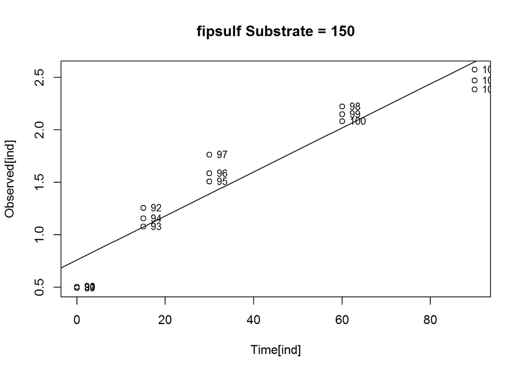